# Data Wrangling

## Part 1: Gathering, Assessing, and Cleaning

## Step 1: Gather

```python
import pandas as pd
import requests
import tweepy
import os
import json
import numpy as np
import matplotlib.pyplot as plt
%matplotlib inline

pd.set_option('display.max_colwidth', -1) # Displays the full text in a column instead of truncating it
```

```python
archive = pd.read_csv('twitter-archive-enhanced.csv')
```

```python
url = 'https://d17h27t6h515a5.cloudfront.net/topher/2017/August/599fd2ad_image-predictions/image-predictions.tsv'
r = requests.get(url)
with open('image_predictions.tsv', 'wb') as file:
    file.write(r.content)
```

```python
predictions = pd.read_csv('image_predictions.tsv', sep='\t')
```

```python
consumer_key = 'YOUR_CONSUMER_KEY_HERE'
consumer_secret = 'YOUR_CONSUMER_SECRET_HERE'
access_token = 'YOUR_ACCESS_TOKEN_HERE'
access_secret = 'YOUR_ACCESS_SECRET_HERE'

auth = tweepy.OAuthHandler(consumer_key, consumer_secret)
auth.set_access_token(access_token, access_secret)

api = tweepy.API(auth, wait_on_rate_limit=True, wait_on_rate_limit_notify=True)
```

```python
#with open('tweet_json.txt', 'w') as file:
#    for tweet in archive.tweet_id:
#        try:
#            jsonstuff = api.get_status(tweet, tweet_mode='extended')._json
#            json.dump(jsonstuff, file)
#            file.write('\n')
#            print(tweet)
#        except tweepy.TweepError as err:
#            print(err.api_code)
```

```python
wanted_keys = ['id', 'favorite_count', 'favorited', 'is_quote_status', 'retweet_count', 'retweeted']
tweet_json_list = []

with open('tweet_json.txt', 'r') as file:
    for line in file:
        json_line = json.loads(line)
        selected_keys = {k:v for k, v in json_line.items() if k in wanted_keys}
        tweet_json_list.append(selected_keys)
```

```python
extended = pd.DataFrame(tweet_json_list)
```

## Step 2: Assess

### 2.1: Visual assessment

```python
archive.head()
```

|  | tweet_id | in_reply_to_status_id | in_reply_to_user_id | timestamp | source | text | retweeted_status_id | retweeted_status_user_id | retweeted_status_timestamp | expanded_urls | rating_numerator | rating_denominator | name | doggo | floofer | pupper | puppo |
| --- | --- | --- | --- | --- | --- | --- | --- | --- | --- | --- | --- | --- | --- | --- | --- | --- | --- |
| 0 | 892420643555336193 | NaN | NaN | 2017-08-01 16:23:56 +0000 | <a href="http://twitter.com/download/iphone" rel="nofollow">Twitter for iPhone</a> | This is Phineas. He's a mystical boy. Only ever appears in the hole of a donut. 13/10 https://t.co/MgUWQ76dJU | NaN | NaN | NaN | https://twitter.com/dog_rates/status/892420643555336193/photo/1 | 13 | 10 | Phineas | None | None | None | None |
| 1 | 892177421306343426 | NaN | NaN | 2017-08-01 00:17:27 +0000 | <a href="http://twitter.com/download/iphone" rel="nofollow">Twitter for iPhone</a> | This is Tilly. She's just checking pup on you. Hopes you're doing ok. If not, she's available for pats, snugs, boops, the whole bit. 13/10 https://t.co/0Xxu71qeIV | NaN | NaN | NaN | https://twitter.com/dog_rates/status/892177421306343426/photo/1 | 13 | 10 | Tilly | None | None | None | None |
| 2 | 891815181378084864 | NaN | NaN | 2017-07-31 00:18:03 +0000 | <a href="http://twitter.com/download/iphone" rel="nofollow">Twitter for iPhone</a> | This is Archie. He is a rare Norwegian Pouncing Corgo. Lives in the tall grass. You never know when one may strike. 12/10 https://t.co/wUnZnhtVJB | NaN | NaN | NaN | https://twitter.com/dog_rates/status/891815181378084864/photo/1 | 12 | 10 | Archie | None | None | None | None |
| 3 | 891689557279858688 | NaN | NaN | 2017-07-30 15:58:51 +0000 | <a href="http://twitter.com/download/iphone" rel="nofollow">Twitter for iPhone</a> | This is Darla. She commenced a snooze mid meal. 13/10 happens to the best of us https://t.co/tD36da7qLQ | NaN | NaN | NaN | https://twitter.com/dog_rates/status/891689557279858688/photo/1 | 13 | 10 | Darla | None | None | None | None |
| 4 | 891327558926688256 | NaN | NaN | 2017-07-29 16:00:24 +0000 | <a href="http://twitter.com/download/iphone" rel="nofollow">Twitter for iPhone</a> | This is Franklin. He would like you to stop calling him "cute." He is a very fierce shark and should be respected as such. 12/10 #BarkWeek https://t.co/AtUZn91f7f | NaN | NaN | NaN | https://twitter.com/dog_rates/status/891327558926688256/photo/1,https://twitter.com/dog_rates/status/891327558926688256/photo/1 | 12 | 10 | Franklin | None | None | None | None |

#### Issues spotted:

##### Dirtiness:

- many NaN values in columns: in_reply_to_status_id, in_reply_to_user_id, retweeted_status_id, retweeted_status_user_id, retweeted_status_timestamp

##### Messiness:

- doggo/floofer/pupper/puppo: four columns for one variable

```python
archive.tail()
```

|  | tweet_id | in_reply_to_status_id | in_reply_to_user_id | timestamp | source | text | retweeted_status_id | retweeted_status_user_id | retweeted_status_timestamp | expanded_urls | rating_numerator | rating_denominator | name | doggo | floofer | pupper | puppo |
| --- | --- | --- | --- | --- | --- | --- | --- | --- | --- | --- | --- | --- | --- | --- | --- | --- | --- |
| 2351 | 666049248165822465 | NaN | NaN | 2015-11-16 00:24:50 +0000 | <a href="http://twitter.com/download/iphone" rel="nofollow">Twitter for iPhone</a> | Here we have a 1949 1st generation vulpix. Enjoys sweat tea and Fox News. Cannot be phased. 5/10 https://t.co/4B7cOc1EDq | NaN | NaN | NaN | https://twitter.com/dog_rates/status/666049248165822465/photo/1 | 5 | 10 | None | None | None | None | None |
| 2352 | 666044226329800704 | NaN | NaN | 2015-11-16 00:04:52 +0000 | <a href="http://twitter.com/download/iphone" rel="nofollow">Twitter for iPhone</a> | This is a purebred Piers Morgan. Loves to Netflix and chill. Always looks like he forgot to unplug the iron. 6/10 https://t.co/DWnyCjf2mx | NaN | NaN | NaN | https://twitter.com/dog_rates/status/666044226329800704/photo/1 | 6 | 10 | a | None | None | None | None |
| 2353 | 666033412701032449 | NaN | NaN | 2015-11-15 23:21:54 +0000 | <a href="http://twitter.com/download/iphone" rel="nofollow">Twitter for iPhone</a> | Here is a very happy pup. Big fan of well-maintained decks. Just look at that tongue. 9/10 would cuddle af https://t.co/y671yMhoiR | NaN | NaN | NaN | https://twitter.com/dog_rates/status/666033412701032449/photo/1 | 9 | 10 | a | None | None | None | None |
| 2354 | 666029285002620928 | NaN | NaN | 2015-11-15 23:05:30 +0000 | <a href="http://twitter.com/download/iphone" rel="nofollow">Twitter for iPhone</a> | This is a western brown Mitsubishi terrier. Upset about leaf. Actually 2 dogs here. 7/10 would walk the shit out of https://t.co/r7mOb2m0UI | NaN | NaN | NaN | https://twitter.com/dog_rates/status/666029285002620928/photo/1 | 7 | 10 | a | None | None | None | None |
| 2355 | 666020888022790149 | NaN | NaN | 2015-11-15 22:32:08 +0000 | <a href="http://twitter.com/download/iphone" rel="nofollow">Twitter for iPhone</a> | Here we have a Japanese Irish Setter. Lost eye in Vietnam (?). Big fan of relaxing on stair. 8/10 would pet https://t.co/BLDqew2Ijj | NaN | NaN | NaN | https://twitter.com/dog_rates/status/666020888022790149/photo/1 | 8 | 10 | None | None | None | None | None |

#### Issues spotted:

##### Dirtiness:

- Single lowercase letter ('a') in the name column instead of None.

```python
predictions.head()
```

|  | tweet_id | jpg_url | img_num | p1 | p1_conf | p1_dog | p2 | p2_conf | p2_dog | p3 | p3_conf | p3_dog |
| --- | --- | --- | --- | --- | --- | --- | --- | --- | --- | --- | --- | --- |
| 0 | 666020888022790149 | https://pbs.twimg.com/media/CT4udn0WwAA0aMy.jpg | 1 | Welsh_springer_spaniel | 0.465074 | True | collie | 0.156665 | True | Shetland_sheepdog | 0.061428 | True |
| 1 | 666029285002620928 | https://pbs.twimg.com/media/CT42GRgUYAA5iDo.jpg | 1 | redbone | 0.506826 | True | miniature_pinscher | 0.074192 | True | Rhodesian_ridgeback | 0.072010 | True |
| 2 | 666033412701032449 | https://pbs.twimg.com/media/CT4521TWwAEvMyu.jpg | 1 | German_shepherd | 0.596461 | True | malinois | 0.138584 | True | bloodhound | 0.116197 | True |
| 3 | 666044226329800704 | https://pbs.twimg.com/media/CT5Dr8HUEAA-lEu.jpg | 1 | Rhodesian_ridgeback | 0.408143 | True | redbone | 0.360687 | True | miniature_pinscher | 0.222752 | True |
| 4 | 666049248165822465 | https://pbs.twimg.com/media/CT5IQmsXIAAKY4A.jpg | 1 | miniature_pinscher | 0.560311 | True | Rottweiler | 0.243682 | True | Doberman | 0.154629 | True |

#### Issues spotted:

##### Dirtiness:

- inconsistent cases (some breed names uppercase, some lowercase)

```python
predictions.tail()
```

|  | tweet_id | jpg_url | img_num | p1 | p1_conf | p1_dog | p2 | p2_conf | p2_dog | p3 | p3_conf | p3_dog |
| --- | --- | --- | --- | --- | --- | --- | --- | --- | --- | --- | --- | --- |
| 2070 | 891327558926688256 | https://pbs.twimg.com/media/DF6hr6BUMAAzZgT.jpg | 2 | basset | 0.555712 | True | English_springer | 0.225770 | True | German_short-haired_pointer | 0.175219 | True |
| 2071 | 891689557279858688 | https://pbs.twimg.com/media/DF_q7IAWsAEuuN8.jpg | 1 | paper_towel | 0.170278 | False | Labrador_retriever | 0.168086 | True | spatula | 0.040836 | False |
| 2072 | 891815181378084864 | https://pbs.twimg.com/media/DGBdLU1WsAANxJ9.jpg | 1 | Chihuahua | 0.716012 | True | malamute | 0.078253 | True | kelpie | 0.031379 | True |
| 2073 | 892177421306343426 | https://pbs.twimg.com/media/DGGmoV4XsAAUL6n.jpg | 1 | Chihuahua | 0.323581 | True | Pekinese | 0.090647 | True | papillon | 0.068957 | True |
| 2074 | 892420643555336193 | https://pbs.twimg.com/media/DGKD1-bXoAAIAUK.jpg | 1 | orange | 0.097049 | False | bagel | 0.085851 | False | banana | 0.076110 | False |

```python
extended.head()
```

|  | favorite_count | favorited | id | is_quote_status | retweet_count | retweeted |
| --- | --- | --- | --- | --- | --- | --- |
| 0 | 38145 | False | 892420643555336193 | False | 8346 | False |
| 1 | 32716 | False | 892177421306343426 | False | 6168 | False |
| 2 | 24632 | False | 891815181378084864 | False | 4082 | False |
| 3 | 41490 | False | 891689557279858688 | False | 8488 | False |
| 4 | 39655 | False | 891327558926688256 | False | 9181 | False |

```python
extended.tail()
```

|  | favorite_count | favorited | id | is_quote_status | retweet_count | retweeted |
| --- | --- | --- | --- | --- | --- | --- |
| 2337 | 108 | False | 666049248165822465 | False | 41 | False |
| 2338 | 295 | False | 666044226329800704 | False | 139 | False |
| 2339 | 124 | False | 666033412701032449 | False | 43 | False |
| 2340 | 128 | False | 666029285002620928 | False | 47 | False |
| 2341 | 2535 | False | 666020888022790149 | False | 507 | False |

### 2.2: Programmatic assessment

```python
archive.info()
```

```
<class 'pandas.core.frame.DataFrame'>
RangeIndex: 2356 entries, 0 to 2355
Data columns (total 17 columns):
tweet_id                      2356 non-null int64
in_reply_to_status_id         78 non-null float64
in_reply_to_user_id           78 non-null float64
timestamp                     2356 non-null object
source                        2356 non-null object
text                          2356 non-null object
retweeted_status_id           181 non-null float64
retweeted_status_user_id      181 non-null float64
retweeted_status_timestamp    181 non-null object
expanded_urls                 2297 non-null object
rating_numerator              2356 non-null int64
rating_denominator            2356 non-null int64
name                          2356 non-null object
doggo                         2356 non-null object
floofer                       2356 non-null object
pupper                        2356 non-null object
puppo                         2356 non-null object
dtypes: float64(4), int64(3), object(10)
memory usage: 313.0+ KB
```

```python
archive.describe()
```

|  | tweet_id | in_reply_to_status_id | in_reply_to_user_id | retweeted_status_id | retweeted_status_user_id | rating_numerator | rating_denominator |
| --- | --- | --- | --- | --- | --- | --- | --- |
| count | 2.356000e+03 | 7.800000e+01 | 7.800000e+01 | 1.810000e+02 | 1.810000e+02 | 2356.000000 | 2356.000000 |
| mean | 7.427716e+17 | 7.455079e+17 | 2.014171e+16 | 7.720400e+17 | 1.241698e+16 | 13.126486 | 10.455433 |
| std | 6.856705e+16 | 7.582492e+16 | 1.252797e+17 | 6.236928e+16 | 9.599254e+16 | 45.876648 | 6.745237 |
| min | 6.660209e+17 | 6.658147e+17 | 1.185634e+07 | 6.661041e+17 | 7.832140e+05 | 0.000000 | 0.000000 |
| 25% | 6.783989e+17 | 6.757419e+17 | 3.086374e+08 | 7.186315e+17 | 4.196984e+09 | 10.000000 | 10.000000 |
| 50% | 7.196279e+17 | 7.038708e+17 | 4.196984e+09 | 7.804657e+17 | 4.196984e+09 | 11.000000 | 10.000000 |
| 75% | 7.993373e+17 | 8.257804e+17 | 4.196984e+09 | 8.203146e+17 | 4.196984e+09 | 12.000000 | 10.000000 |
| max | 8.924206e+17 | 8.862664e+17 | 8.405479e+17 | 8.874740e+17 | 7.874618e+17 | 1776.000000 | 170.000000 |

#### Issues spotted:

##### Dirtiness:

- Many many null values in previously-mentioned columns; some nulls in expanded_urls
- Invalid data types: timestamp & retweeted_status_timestamp
- Invalid data: the project brief specified only original tweets, so the 78 replies and 181 retweets (and any others) are invalid for this project.
- 0 values in rating_numerator and rating_denominator

```python
predictions.info()
```

```
<class 'pandas.core.frame.DataFrame'>
RangeIndex: 2075 entries, 0 to 2074
Data columns (total 12 columns):
tweet_id    2075 non-null int64
jpg_url     2075 non-null object
img_num     2075 non-null int64
p1          2075 non-null object
p1_conf     2075 non-null float64
p1_dog      2075 non-null bool
p2          2075 non-null object
p2_conf     2075 non-null float64
p2_dog      2075 non-null bool
p3          2075 non-null object
p3_conf     2075 non-null float64
p3_dog      2075 non-null bool
dtypes: bool(3), float64(3), int64(2), object(4)
memory usage: 152.1+ KB
```

```python
predictions.describe()
```

|  | tweet_id | img_num | p1_conf | p2_conf | p3_conf |
| --- | --- | --- | --- | --- | --- |
| count | 2.075000e+03 | 2075.000000 | 2075.000000 | 2.075000e+03 | 2.075000e+03 |
| mean | 7.384514e+17 | 1.203855 | 0.594548 | 1.345886e-01 | 6.032417e-02 |
| std | 6.785203e+16 | 0.561875 | 0.271174 | 1.006657e-01 | 5.090593e-02 |
| min | 6.660209e+17 | 1.000000 | 0.044333 | 1.011300e-08 | 1.740170e-10 |
| 25% | 6.764835e+17 | 1.000000 | 0.364412 | 5.388625e-02 | 1.622240e-02 |
| 50% | 7.119988e+17 | 1.000000 | 0.588230 | 1.181810e-01 | 4.944380e-02 |
| 75% | 7.932034e+17 | 1.000000 | 0.843855 | 1.955655e-01 | 9.180755e-02 |
| max | 8.924206e+17 | 4.000000 | 1.000000 | 4.880140e-01 | 2.734190e-01 |

```python
extended.info()
```

```
<class 'pandas.core.frame.DataFrame'>
RangeIndex: 2342 entries, 0 to 2341
Data columns (total 6 columns):
favorite_count     2342 non-null int64
favorited          2342 non-null bool
id                 2342 non-null int64
is_quote_status    2342 non-null bool
retweet_count      2342 non-null int64
retweeted          2342 non-null bool
dtypes: bool(3), int64(3)
memory usage: 61.8 KB
```

```python
extended.describe()
```

|  | favorite_count | id | retweet_count |
| --- | --- | --- | --- |
| count | 2342.000000 | 2.342000e+03 | 2342.000000 |
| mean | 7984.561913 | 7.422212e+17 | 2943.631939 |
| std | 12359.878226 | 6.832408e+16 | 4950.322617 |
| min | 0.000000 | 6.660209e+17 | 0.000000 |
| 25% | 1378.250000 | 6.783509e+17 | 591.500000 |
| 50% | 3473.500000 | 7.186224e+17 | 1374.500000 |
| 75% | 9781.250000 | 7.986971e+17 | 3432.250000 |
| max | 164669.000000 | 8.924206e+17 | 83898.000000 |

#### Issues spotted:

##### Dirtiness:

- 0 values in favorite_count and retweet_count seem unlikely

##### Messiness:

- This information should be joined with the archive information

I want to pick out a few more variables/areas that I think might have issues...:

```python
archive.name.value_counts()
```

```
None            745
a               55
Charlie         12
Cooper          11
Lucy            11
Oliver          11
Lola            10
Tucker          10
Penny           10
Bo              9
Winston         9
Sadie           8
the             8
Buddy           7
Toby            7
an              7
Bailey          7
Daisy           7
Leo             6
Oscar           6
Stanley         6
Milo            6
Scout           6
Jax             6
Bella           6
Koda            6
Dave            6
Rusty           6
Jack            6
Oakley          5
               ..
Stefan          1
all             1
Shnuggles       1
Huck            1
Nugget          1
Storkson        1
Major           1
Doobert         1
Laika           1
Angel           1
Ralf            1
Stella          1
Dook            1
Jazzy           1
Kaiya           1
Lance           1
Leonidas        1
Tedrick         1
Mike            1
Hector          1
Stuart          1
Billy           1
Norman          1
Emanuel         1
Alexanderson    1
Kallie          1
such            1
Bookstore       1
Raphael         1
Mairi           1
Name: name, Length: 957, dtype: int64
```

#### Issues spotted:

##### Dirtiness:

- Several names look invalid, including 'a', 'the', 'very,' 'an,' and 'unacceptable.'

```python
archive[archive['rating_denominator'] != 10]
```

|  | tweet_id | in_reply_to_status_id | in_reply_to_user_id | timestamp | source | text | retweeted_status_id | retweeted_status_user_id | retweeted_status_timestamp | expanded_urls | rating_numerator | rating_denominator | name | doggo | floofer | pupper | puppo |
| --- | --- | --- | --- | --- | --- | --- | --- | --- | --- | --- | --- | --- | --- | --- | --- | --- | --- |
| 313 | 835246439529840640 | 8.352460e+17 | 2.625958e+07 | 2017-02-24 21:54:03 +0000 | <a href="http://twitter.com/download/iphone" rel="nofollow">Twitter for iPhone</a> | @jonnysun @Lin_Manuel ok jomny I know you're excited but 960/00 isn't a valid rating, 13/10 is tho | NaN | NaN | NaN | NaN | 960 | 0 | None | None | None | None | None |
| 342 | 832088576586297345 | 8.320875e+17 | 3.058208e+07 | 2017-02-16 04:45:50 +0000 | <a href="http://twitter.com/download/iphone" rel="nofollow">Twitter for iPhone</a> | @docmisterio account started on 11/15/15 | NaN | NaN | NaN | NaN | 11 | 15 | None | None | None | None | None |
| 433 | 820690176645140481 | NaN | NaN | 2017-01-15 17:52:40 +0000 | <a href="http://twitter.com/download/iphone" rel="nofollow">Twitter for iPhone</a> | The floofs have been released I repeat the floofs have been released. 84/70 https://t.co/NIYC820tmd | NaN | NaN | NaN | https://twitter.com/dog_rates/status/820690176645140481/photo/1,https://twitter.com/dog_rates/status/820690176645140481/photo/1,https://twitter.com/dog_rates/status/820690176645140481/photo/1 | 84 | 70 | None | None | None | None | None |
| 516 | 810984652412424192 | NaN | NaN | 2016-12-19 23:06:23 +0000 | <a href="http://twitter.com/download/iphone" rel="nofollow">Twitter for iPhone</a> | Meet Sam. She smiles 24/7 &amp; secretly aspires to be a reindeer. \nKeep Sam smiling by clicking and sharing this link:\nhttps://t.co/98tB8y7y7t https://t.co/LouL5vdvxx | NaN | NaN | NaN | https://www.gofundme.com/sams-smile,https://twitter.com/dog_rates/status/810984652412424192/photo/1 | 24 | 7 | Sam | None | None | None | None |
| 784 | 775096608509886464 | NaN | NaN | 2016-09-11 22:20:06 +0000 | <a href="http://twitter.com/download/iphone" rel="nofollow">Twitter for iPhone</a> | RT @dog_rates: After so many requests, this is Bretagne. She was the last surviving 9/11 search dog, and our second ever 14/10. RIP https:/… | 7.403732e+17 | 4.196984e+09 | 2016-06-08 02:41:38 +0000 | https://twitter.com/dog_rates/status/740373189193256964/photo/1,https://twitter.com/dog_rates/status/740373189193256964/photo/1,https://twitter.com/dog_rates/status/740373189193256964/photo/1,https://… | 9 | 11 | None | None | None | None | None |
| 902 | 758467244762497024 | NaN | NaN | 2016-07-28 01:00:57 +0000 | <a href="http://twitter.com/download/iphone" rel="nofollow">Twitter for iPhone</a> | Why does this never happen at my front door... 165/150 https://t.co/HmwrdfEfUE | NaN | NaN | NaN | https://twitter.com/dog_rates/status/758467244762497024/video/1 | 165 | 150 | None | None | None | None | None |
| 1068 | 740373189193256964 | NaN | NaN | 2016-06-08 02:41:38 +0000 | <a href="http://twitter.com/download/iphone" rel="nofollow">Twitter for iPhone</a> | After so many requests, this is Bretagne. She was the last surviving 9/11 search dog, and our second ever 14/10. RIP https://t.co/XAVDNDaVgQ | NaN | NaN | NaN | https://twitter.com/dog_rates/status/740373189193256964/photo/1,https://twitter.com/dog_rates/status/740373189193256964/photo/1,https://twitter.com/dog_rates/status/740373189193256964/photo/1,https://… | 9 | 11 | None | None | None | None | None |
| 1120 | 731156023742988288 | NaN | NaN | 2016-05-13 16:15:54 +0000 | <a href="http://twitter.com/download/iphone" rel="nofollow">Twitter for iPhone</a> | Say hello to this unbelievably well behaved squad of doggos. 204/170 would try to pet all at once https://t.co/yGQI3He3xv | NaN | NaN | NaN | https://twitter.com/dog_rates/status/731156023742988288/photo/1 | 204 | 170 | this | None | None | None | None |
| 1165 | 722974582966214656 | NaN | NaN | 2016-04-21 02:25:47 +0000 | <a href="http://twitter.com/download/iphone" rel="nofollow">Twitter for iPhone</a> | Happy 4/20 from the squad! 13/10 for all https://t.co/eV1diwds8a | NaN | NaN | NaN | https://twitter.com/dog_rates/status/722974582966214656/photo/1 | 4 | 20 | None | None | None | None | None |
| 1202 | 716439118184652801 | NaN | NaN | 2016-04-03 01:36:11 +0000 | <a href="http://twitter.com/download/iphone" rel="nofollow">Twitter for iPhone</a> | This is Bluebert. He just saw that both #FinalFur match ups are split 50/50. Amazed af. 11/10 https://t.co/Kky1DPG4iq | NaN | NaN | NaN | https://twitter.com/dog_rates/status/716439118184652801/photo/1 | 50 | 50 | Bluebert | None | None | None | None |
| 1228 | 713900603437621249 | NaN | NaN | 2016-03-27 01:29:02 +0000 | <a href="http://twitter.com/download/iphone" rel="nofollow">Twitter for iPhone</a> | Happy Saturday here's 9 puppers on a bench. 99/90 good work everybody https://t.co/mpvaVxKmc1 | NaN | NaN | NaN | https://twitter.com/dog_rates/status/713900603437621249/photo/1 | 99 | 90 | None | None | None | None | None |
| 1254 | 710658690886586372 | NaN | NaN | 2016-03-18 02:46:49 +0000 | <a href="http://twitter.com/download/iphone" rel="nofollow">Twitter for iPhone</a> | Here's a brigade of puppers. All look very prepared for whatever happens next. 80/80 https://t.co/0eb7R1Om12 | NaN | NaN | NaN | https://twitter.com/dog_rates/status/710658690886586372/photo/1 | 80 | 80 | None | None | None | None | None |
| 1274 | 709198395643068416 | NaN | NaN | 2016-03-14 02:04:08 +0000 | <a href="http://twitter.com/download/iphone" rel="nofollow">Twitter for iPhone</a> | From left to right:\nCletus, Jerome, Alejandro, Burp, &amp; Titson\nNone know where camera is. 45/50 would hug all at once https://t.co/sedre1ivTK | NaN | NaN | NaN | https://twitter.com/dog_rates/status/709198395643068416/photo/1 | 45 | 50 | None | None | None | None | None |
| 1351 | 704054845121142784 | NaN | NaN | 2016-02-28 21:25:30 +0000 | <a href="http://twitter.com/download/iphone" rel="nofollow">Twitter for iPhone</a> | Here is a whole flock of puppers. 60/50 I'll take the lot https://t.co/9dpcw6MdWa | NaN | NaN | NaN | https://twitter.com/dog_rates/status/704054845121142784/photo/1 | 60 | 50 | a | None | None | None | None |
| 1433 | 697463031882764288 | NaN | NaN | 2016-02-10 16:51:59 +0000 | <a href="http://twitter.com/download/iphone" rel="nofollow">Twitter for iPhone</a> | Happy Wednesday here's a bucket of pups. 44/40 would pet all at once https://t.co/HppvrYuamZ | NaN | NaN | NaN | https://twitter.com/dog_rates/status/697463031882764288/photo/1 | 44 | 40 | None | None | None | None | None |
| 1598 | 686035780142297088 | 6.860340e+17 | 4.196984e+09 | 2016-01-10 04:04:10 +0000 | <a href="http://twitter.com/download/iphone" rel="nofollow">Twitter for iPhone</a> | Yes I do realize a rating of 4/20 would've been fitting. However, it would be unjust to give these cooperative pups that low of a rating | NaN | NaN | NaN | NaN | 4 | 20 | None | None | None | None | None |
| 1634 | 684225744407494656 | 6.842229e+17 | 4.196984e+09 | 2016-01-05 04:11:44 +0000 | <a href="http://twitter.com/download/iphone" rel="nofollow">Twitter for iPhone</a> | Two sneaky puppers were not initially seen, moving the rating to 143/130. Please forgive us. Thank you https://t.co/kRK51Y5ac3 | NaN | NaN | NaN | https://twitter.com/dog_rates/status/684225744407494656/photo/1,https://twitter.com/dog_rates/status/684225744407494656/photo/1 | 143 | 130 | None | None | None | None | None |
| 1635 | 684222868335505415 | NaN | NaN | 2016-01-05 04:00:18 +0000 | <a href="http://twitter.com/download/iphone" rel="nofollow">Twitter for iPhone</a> | Someone help the girl is being mugged. Several are distracting her while two steal her shoes. Clever puppers 121/110 https://t.co/1zfnTJLt55 | NaN | NaN | NaN | https://twitter.com/dog_rates/status/684222868335505415/photo/1 | 121 | 110 | None | None | None | None | None |
| 1662 | 682962037429899265 | NaN | NaN | 2016-01-01 16:30:13 +0000 | <a href="http://twitter.com/download/iphone" rel="nofollow">Twitter for iPhone</a> | This is Darrel. He just robbed a 7/11 and is in a high speed police chase. Was just spotted by the helicopter 10/10 https://t.co/7EsP8LmSp5 | NaN | NaN | NaN | https://twitter.com/dog_rates/status/682962037429899265/photo/1 | 7 | 11 | Darrel | None | None | None | None |
| 1663 | 682808988178739200 | 6.827884e+17 | 4.196984e+09 | 2016-01-01 06:22:03 +0000 | <a href="http://twitter.com/download/iphone" rel="nofollow">Twitter for iPhone</a> | I'm aware that I could've said 20/16, but here at WeRateDogs we are very professional. An inconsistent rating scale is simply irresponsible | NaN | NaN | NaN | NaN | 20 | 16 | None | None | None | None | None |
| 1779 | 677716515794329600 | NaN | NaN | 2015-12-18 05:06:23 +0000 | <a href="http://twitter.com/download/iphone" rel="nofollow">Twitter for iPhone</a> | IT'S PUPPERGEDDON. Total of 144/120 ...I think https://t.co/ZanVtAtvIq | NaN | NaN | NaN | https://twitter.com/dog_rates/status/677716515794329600/photo/1 | 144 | 120 | None | None | None | None | None |
| 1843 | 675853064436391936 | NaN | NaN | 2015-12-13 01:41:41 +0000 | <a href="http://twitter.com/download/iphone" rel="nofollow">Twitter for iPhone</a> | Here we have an entire platoon of puppers. Total score: 88/80 would pet all at once https://t.co/y93p6FLvVw | NaN | NaN | NaN | https://twitter.com/dog_rates/status/675853064436391936/photo/1,https://twitter.com/dog_rates/status/675853064436391936/photo/1 | 88 | 80 | None | None | None | None | None |
| 2335 | 666287406224695296 | NaN | NaN | 2015-11-16 16:11:11 +0000 | <a href="http://twitter.com/download/iphone" rel="nofollow">Twitter for iPhone</a> | This is an Albanian 3 1/2 legged Episcopalian. Loves well-polished hardwood flooring. Penis on the collar. 9/10 https://t.co/d9NcXFKwLv | NaN | NaN | NaN | https://twitter.com/dog_rates/status/666287406224695296/photo/1 | 1 | 2 | an | None | None | None | None |

#### Issues spotted:

##### Dirtiness:

- Several mistakes in denominators and their associated numerators (9/11, 4/20, etc.). The script appears to have pulled the wrong fraction from the tweet in those cases. Five of these are in original tweets: row 1068, 1165, 1202, 1662, 2335. I think they have to be fixed manually this time.

```python
predictions[predictions['jpg_url'].duplicated()]
predictions[predictions['jpg_url'] == 'https://pbs.twimg.com/media/DA7iHL5U0AA1OQo.jpg']
```

|  | tweet_id | jpg_url | img_num | p1 | p1_conf | p1_dog | p2 | p2_conf | p2_dog | p3 | p3_conf | p3_dog |
| --- | --- | --- | --- | --- | --- | --- | --- | --- | --- | --- | --- | --- |
| 1970 | 868880397819494401 | https://pbs.twimg.com/media/DA7iHL5U0AA1OQo.jpg | 1 | laptop | 0.153718 | False | French_bulldog | 0.099984 | True | printer | 0.07713 | False |
| 1992 | 873697596434513921 | https://pbs.twimg.com/media/DA7iHL5U0AA1OQo.jpg | 1 | laptop | 0.153718 | False | French_bulldog | 0.099984 | True | printer | 0.07713 | False |

#### Issues spotted:

##### Dirtiness:

- Duplicated jpg urls/predictions with different tweet ids

```python
extended[extended['favorite_count'] == 0]
```

|  | favorite_count | favorited | id | is_quote_status | retweet_count | retweeted |
| --- | --- | --- | --- | --- | --- | --- |
| 31 | 0 | False | 886054160059072513 | True | 105 | False |
| 35 | 0 | False | 885311592912609280 | False | 18237 | False |
| 67 | 0 | False | 879130579576475649 | False | 6721 | False |
| 72 | 0 | False | 878404777348136964 | False | 1270 | False |
| 73 | 0 | False | 878316110768087041 | False | 6558 | False |
| 77 | 0 | False | 877611172832227328 | False | 80 | False |
| 90 | 0 | False | 874434818259525634 | False | 14574 | False |
| 95 | 0 | False | 873337748698140672 | False | 1572 | False |
| 106 | 0 | False | 871166179821445120 | False | 5678 | False |
| 120 | 0 | False | 868639477480148993 | False | 2103 | False |
| 126 | 0 | False | 867072653475098625 | False | 121 | False |
| 132 | 0 | False | 866094527597207552 | False | 8448 | False |
| 141 | 0 | False | 863471782782697472 | False | 2486 | False |
| 153 | 0 | False | 860981674716409858 | False | 2195 | False |
| 154 | 0 | False | 860924035999428608 | False | 838 | False |
| 159 | 0 | False | 860177593139703809 | False | 31506 | False |
| 165 | 0 | False | 858860390427611136 | False | 8343 | False |
| 174 | 0 | False | 857062103051644929 | False | 177 | False |
| 176 | 0 | False | 856602993587888130 | False | 11011 | False |
| 179 | 0 | False | 856330835276025856 | False | 700 | False |
| 188 | 0 | False | 855245323840757760 | False | 6198 | False |
| 189 | 0 | False | 855138241867124737 | False | 47 | False |
| 198 | 0 | False | 852936405516943360 | False | 2104 | False |
| 205 | 0 | False | 851953902622658560 | False | 10112 | False |
| 206 | 0 | False | 851861385021730816 | False | 23 | False |
| 216 | 0 | False | 849668094696017920 | False | 5235 | False |
| 224 | 0 | False | 847978865427394560 | False | 3448 | False |
| 225 | 0 | False | 847971574464610304 | False | 452 | False |
| 243 | 0 | False | 845098359547420673 | False | 8151 | False |
| 258 | 0 | False | 841833993020538882 | False | 16400 | False |
| ... | ... | ... | ... | ... | ... | ... |
| 762 | 0 | False | 776249906839351296 | False | 10005 | False |
| 767 | 0 | False | 775898661951791106 | False | 17949 | False |
| 782 | 0 | False | 773336787167145985 | False | 5556 | False |
| 788 | 0 | False | 772615324260794368 | False | 3680 | False |
| 799 | 0 | False | 771171053431250945 | False | 8242 | False |
| 803 | 0 | False | 771004394259247104 | False | 240 | False |
| 809 | 0 | False | 770093767776997377 | False | 3308 | False |
| 813 | 0 | False | 769335591808995329 | False | 8371 | False |
| 816 | 0 | False | 768909767477751808 | False | 2941 | False |
| 820 | 0 | False | 768554158521745409 | False | 6337 | False |
| 828 | 0 | False | 766864461642756096 | False | 6149 | False |
| 834 | 0 | False | 766078092750233600 | False | 2827 | False |
| 847 | 0 | False | 763167063695355904 | False | 3277 | False |
| 855 | 0 | False | 761750502866649088 | False | 4275 | False |
| 859 | 0 | False | 761371037149827077 | False | 19485 | False |
| 872 | 0 | False | 760153949710192640 | False | 34 | False |
| 877 | 0 | False | 759566828574212096 | False | 22897 | False |
| 882 | 0 | False | 759159934323924993 | False | 1262 | False |
| 895 | 0 | False | 757729163776290825 | False | 8779 | False |
| 898 | 0 | False | 757597904299253760 | False | 315 | False |
| 913 | 0 | False | 754874841593970688 | False | 8673 | False |
| 923 | 0 | False | 753298634498793472 | False | 6242 | False |
| 929 | 0 | False | 752701944171524096 | False | 3119 | False |
| 935 | 0 | False | 752309394570878976 | False | 18041 | False |
| 998 | 0 | False | 747242308580548608 | False | 3098 | False |
| 1009 | 0 | False | 746521445350707200 | False | 1057 | False |
| 1029 | 0 | False | 743835915802583040 | False | 2237 | False |
| 1228 | 0 | False | 711998809858043904 | False | 134 | False |
| 2245 | 0 | False | 667550904950915073 | False | 35 | False |
| 2246 | 0 | False | 667550882905632768 | False | 33 | False |

168 rows × 6 columns

```python
extended[extended['retweet_count'] == 0]
```

|  | favorite_count | favorited | id | is_quote_status | retweet_count | retweeted |
| --- | --- | --- | --- | --- | --- | --- |
| 283 | 149 | False | 838085839343206401 | False | 0 | False |

#### Issues spotted:

##### Dirtiness:

- Not sure what to make of these 0 values for favorite and retweet count. They seem unlikely, but the other info appears valid.

## Issues Summary:

### Quality (Dirty Data):

#### Tweet archive:

- many NaN values in columns: in_reply_to_status_id, in_reply_to_user_id, retweeted_status_id, retweeted_status_user_id, retweeted_status_timestamp, expanded_urls
- Invalid data types: timestamp, retweeted_status_timestamp
- Invalid data in retweets/replies, according to the project brief
- 0 values in rating_numerator and rating_denominator
- Several names look invalid, including 'a', 'the', 'very,' 'an,' and 'unacceptable.'
- Five tweets pulled the wrong fraction as their rating (4/20, 7/11, etc.)

#### Predictions:

- Inconsistent cases (some breed names uppercase, some lowercase)
- Duplicated jpg urls/predictions with different tweet ids

#### Extended tweet info (from the API):

- 0 values in favorite_count and retweet_count seem unlikely

### Tidiness (Messy Data):

#### Tweet archive:

- doggo/floofer/pupper/puppo: four columns for one variable
- Contains info about dogs and info about tweets in one table

#### Extended tweet info:

- This information does not need to be in its own table

## Step 3: Clean

- Merge archive and extended tables to fill in some missing values (this will also address tidiness issue #3)
- Correct invalid data types: timestamp and retweeted_status_timestamp to datetime
- Several rating and name mistakes appear to be retweets or replies: delete retweets/replies and reassess (can delete retweet/reply-relevant columns after this)
- Fill in 0 values in favorite_count and retweet_count (Spoiler alert: this gets taken care of by deleting retweets/replies)
- Fix 0 value rating numerators/denominators
- Manually fix five invalid ratings
- Go through invalid names and change to correct name, if one exists, or None
- Change inconsistent cases in predictions to all lowercase
- Append extended_urls from archive to predictions and reassess duplicates
- Create new table to separate dog info from tweet info
- Melt doggo/floofer/pupper/puppo columns.

#### Define:

- Merge archive and extended tables to fill in some missing values (this will also address tidiness issue #3)

#### Code:

```python
archive_clean = archive.copy()
predictions_clean = predictions.copy()
extended_clean = extended.copy()
```

```python
full_archive = pd.merge(archive_clean, extended_clean, how='left', left_on='tweet_id', right_on='id').drop('id', axis=1)
```

#### Test:

```python
full_archive.head()
```

|  | tweet_id | in_reply_to_status_id | in_reply_to_user_id | timestamp | source | text | retweeted_status_id | retweeted_status_user_id | retweeted_status_timestamp | expanded_urls | ... | name | doggo | floofer | pupper | puppo | favorite_count | favorited | is_quote_status | retweet_count | retweeted |
| --- | --- | --- | --- | --- | --- | --- | --- | --- | --- | --- | --- | --- | --- | --- | --- | --- | --- | --- | --- | --- | --- |
| 0 | 892420643555336193 | NaN | NaN | 2017-08-01 16:23:56 +0000 | <a href="http://twitter.com/download/iphone" rel="nofollow">Twitter for iPhone</a> | This is Phineas. He's a mystical boy. Only ever appears in the hole of a donut. 13/10 https://t.co/MgUWQ76dJU | NaN | NaN | NaN | https://twitter.com/dog_rates/status/892420643555336193/photo/1 | ... | Phineas | None | None | None | None | 38145.0 | False | False | 8346.0 | False |
| 1 | 892177421306343426 | NaN | NaN | 2017-08-01 00:17:27 +0000 | <a href="http://twitter.com/download/iphone" rel="nofollow">Twitter for iPhone</a> | This is Tilly. She's just checking pup on you. Hopes you're doing ok. If not, she's available for pats, snugs, boops, the whole bit. 13/10 https://t.co/0Xxu71qeIV | NaN | NaN | NaN | https://twitter.com/dog_rates/status/892177421306343426/photo/1 | ... | Tilly | None | None | None | None | 32716.0 | False | False | 6168.0 | False |
| 2 | 891815181378084864 | NaN | NaN | 2017-07-31 00:18:03 +0000 | <a href="http://twitter.com/download/iphone" rel="nofollow">Twitter for iPhone</a> | This is Archie. He is a rare Norwegian Pouncing Corgo. Lives in the tall grass. You never know when one may strike. 12/10 https://t.co/wUnZnhtVJB | NaN | NaN | NaN | https://twitter.com/dog_rates/status/891815181378084864/photo/1 | ... | Archie | None | None | None | None | 24632.0 | False | False | 4082.0 | False |
| 3 | 891689557279858688 | NaN | NaN | 2017-07-30 15:58:51 +0000 | <a href="http://twitter.com/download/iphone" rel="nofollow">Twitter for iPhone</a> | This is Darla. She commenced a snooze mid meal. 13/10 happens to the best of us https://t.co/tD36da7qLQ | NaN | NaN | NaN | https://twitter.com/dog_rates/status/891689557279858688/photo/1 | ... | Darla | None | None | None | None | 41490.0 | False | False | 8488.0 | False |
| 4 | 891327558926688256 | NaN | NaN | 2017-07-29 16:00:24 +0000 | <a href="http://twitter.com/download/iphone" rel="nofollow">Twitter for iPhone</a> | This is Franklin. He would like you to stop calling him "cute." He is a very fierce shark and should be respected as such. 12/10 #BarkWeek https://t.co/AtUZn91f7f | NaN | NaN | NaN | https://twitter.com/dog_rates/status/891327558926688256/photo/1,https://twitter.com/dog_rates/status/891327558926688256/photo/1 | ... | Franklin | None | None | None | None | 39655.0 | False | False | 9181.0 | False |

5 rows × 22 columns

#### Define:

- Correct invalid data types: timestamp and retweeted_status_timestamp to datetime
- Merge appears to have also turned ints into floats and bools to str, turn to int and bool respectively

```python
full_archive.timestamp = pd.to_datetime(full_archive.timestamp, errors='coerce', infer_datetime_format=True)
full_archive.retweeted_status_timestamp = pd.to_datetime(full_archive.retweeted_status_timestamp, errors='coerce', infer_datetime_format=True)
```

```python
full_archive.favorite_count = full_archive.favorite_count.fillna(0).astype(int)
full_archive.retweet_count = full_archive.retweet_count.fillna(0).astype(int)
full_archive.favorited = full_archive.favorited.astype(bool)
full_archive.retweeted = full_archive.retweeted.astype(bool)
full_archive.is_quote_status = full_archive.is_quote_status.astype(bool)
```

#### Test:

```python
full_archive.info()
```

```
<class 'pandas.core.frame.DataFrame'>
Int64Index: 2356 entries, 0 to 2355
Data columns (total 22 columns):
tweet_id                      2356 non-null int64
in_reply_to_status_id         78 non-null float64
in_reply_to_user_id           78 non-null float64
timestamp                     2356 non-null datetime64[ns]
source                        2356 non-null object
text                          2356 non-null object
retweeted_status_id           181 non-null float64
retweeted_status_user_id      181 non-null float64
retweeted_status_timestamp    181 non-null datetime64[ns]
expanded_urls                 2297 non-null object
rating_numerator              2356 non-null int64
rating_denominator            2356 non-null int64
name                          2356 non-null object
doggo                         2356 non-null object
floofer                       2356 non-null object
pupper                        2356 non-null object
puppo                         2356 non-null object
favorite_count                2356 non-null int64
favorited                     2356 non-null bool
is_quote_status               2356 non-null bool
retweet_count                 2356 non-null int64
retweeted                     2356 non-null bool
dtypes: bool(3), datetime64[ns](2), float64(4), int64(5), object(8)
memory usage: 375.0+ KB
```

#### Define:

- Several rating and name mistakes appear to be retweets or replies: delete retweets/replies and reassess (can delete retweet/reply-relevant columns after this)

#### Code:

```python
full_archive = full_archive[full_archive['in_reply_to_status_id'].isnull()]
full_archive = full_archive[full_archive['retweeted'] == False]
full_archive = full_archive[full_archive['is_quote_status'] == False]
full_archive = full_archive[full_archive['favorited'] == False]
```

```python
full_archive = full_archive[full_archive['retweeted_status_id'].isnull()] # 'Retweeted' missed a few
```

#### Test:

```python
full_archive.info()
```

```
<class 'pandas.core.frame.DataFrame'>
Int64Index: 2067 entries, 0 to 2355
Data columns (total 22 columns):
tweet_id                      2067 non-null int64
in_reply_to_status_id         0 non-null float64
in_reply_to_user_id           0 non-null float64
timestamp                     2067 non-null datetime64[ns]
source                        2067 non-null object
text                          2067 non-null object
retweeted_status_id           0 non-null float64
retweeted_status_user_id      0 non-null float64
retweeted_status_timestamp    0 non-null datetime64[ns]
expanded_urls                 2064 non-null object
rating_numerator              2067 non-null int64
rating_denominator            2067 non-null int64
name                          2067 non-null object
doggo                         2067 non-null object
floofer                       2067 non-null object
pupper                        2067 non-null object
puppo                         2067 non-null object
favorite_count                2067 non-null int64
favorited                     2067 non-null bool
is_quote_status               2067 non-null bool
retweet_count                 2067 non-null int64
retweeted                     2067 non-null bool
dtypes: bool(3), datetime64[ns](2), float64(4), int64(5), object(8)
memory usage: 329.0+ KB
```

#### Define:

- Irrelevant columns (relating to retweets/replies) can now be dropped.

#### Code:

```python
full_archive = full_archive.drop(['in_reply_to_status_id', 'in_reply_to_user_id', 'retweeted_status_id',
                                            'retweeted_status_user_id', 'retweeted_status_timestamp', 'favorited',
                                            'is_quote_status', 'retweeted'], axis=1)
```

#### Test:

```python
full_archive.info()
```

```
<class 'pandas.core.frame.DataFrame'>
Int64Index: 2067 entries, 0 to 2355
Data columns (total 14 columns):
tweet_id              2067 non-null int64
timestamp             2067 non-null datetime64[ns]
source                2067 non-null object
text                  2067 non-null object
expanded_urls         2064 non-null object
rating_numerator      2067 non-null int64
rating_denominator    2067 non-null int64
name                  2067 non-null object
doggo                 2067 non-null object
floofer               2067 non-null object
pupper                2067 non-null object
puppo                 2067 non-null object
favorite_count        2067 non-null int64
retweet_count         2067 non-null int64
dtypes: datetime64[ns](1), int64(5), object(8)
memory usage: 242.2+ KB
```

#### Define:

- Fill in 0 values in favorite_count and retweet_count

#### Code/Test:

```python
full_archive[full_archive['favorite_count'] == 0]
full_archive[full_archive['retweet_count'] == 0] # It turns out these were taken care of by deleting retweets/replies!
```

|  | tweet_id | timestamp | source | text | expanded_urls | rating_numerator | rating_denominator | name | doggo | floofer | pupper | puppo | favorite_count | retweet_count |
| --- | --- | --- | --- | --- | --- | --- | --- | --- | --- | --- | --- | --- | --- | --- |

#### Define:

- Fill in 0s in rating numerators and denominators

#### Code:

```python
full_archive[full_archive['rating_denominator'] == 0] # This must have also been taken care of by the replies/retweets purge.
```

|  | tweet_id | timestamp | source | text | expanded_urls | rating_numerator | rating_denominator | name | doggo | floofer | pupper | puppo | favorite_count | retweet_count |
| --- | --- | --- | --- | --- | --- | --- | --- | --- | --- | --- | --- | --- | --- | --- |

```python
full_archive[full_archive['rating_numerator'] == 0] # This one turns out to be a joke and can be deleted as well.
```

|  | tweet_id | timestamp | source | text | expanded_urls | rating_numerator | rating_denominator | name | doggo | floofer | pupper | puppo | favorite_count | retweet_count |
| --- | --- | --- | --- | --- | --- | --- | --- | --- | --- | --- | --- | --- | --- | --- |
| 315 | 835152434251116546 | 2017-02-24 15:40:31 | <a href="http://twitter.com/download/iphone" rel="nofollow">Twitter for iPhone</a> | When you're so blinded by your systematic plagiarism that you forget what day it is. 0/10 https://t.co/YbEJPkg4Ag | https://twitter.com/dog_rates/status/835152434251116546/photo/1,https://twitter.com/dog_rates/status/835152434251116546/photo/1,https://twitter.com/dog_rates/status/835152434251116546/photo/1 | 0 | 10 | None | None | None | None | None | 23644 | 3253 |

```python
full_archive = full_archive.drop(315, axis=0)
```

#### Test:

```python
full_archive[full_archive['rating_numerator'] == 0]
```

|  | tweet_id | timestamp | source | text | expanded_urls | rating_numerator | rating_denominator | name | doggo | floofer | pupper | puppo | favorite_count | retweet_count |
| --- | --- | --- | --- | --- | --- | --- | --- | --- | --- | --- | --- | --- | --- | --- |

#### Define:

- Manually fix five invalid ratings in rows 1068, 1165, 1202, 1662, 2335.

#### Code:

```python
full_archive[full_archive['rating_denominator'] != 10]
```

|  | tweet_id | timestamp | source | text | expanded_urls | rating_numerator | rating_denominator | name | doggo | floofer | pupper | puppo | favorite_count | retweet_count |
| --- | --- | --- | --- | --- | --- | --- | --- | --- | --- | --- | --- | --- | --- | --- |
| 433 | 820690176645140481 | 2017-01-15 17:52:40 | <a href="http://twitter.com/download/iphone" rel="nofollow">Twitter for iPhone</a> | The floofs have been released I repeat the floofs have been released. 84/70 https://t.co/NIYC820tmd | https://twitter.com/dog_rates/status/820690176645140481/photo/1,https://twitter.com/dog_rates/status/820690176645140481/photo/1,https://twitter.com/dog_rates/status/820690176645140481/photo/1 | 84 | 70 | None | None | None | None | None | 12998 | 3530 |
| 516 | 810984652412424192 | 2016-12-19 23:06:23 | <a href="http://twitter.com/download/iphone" rel="nofollow">Twitter for iPhone</a> | Meet Sam. She smiles 24/7 &amp; secretly aspires to be a reindeer. \nKeep Sam smiling by clicking and sharing this link:\nhttps://t.co/98tB8y7y7t https://t.co/LouL5vdvxx | https://www.gofundme.com/sams-smile,https://twitter.com/dog_rates/status/810984652412424192/photo/1 | 24 | 7 | Sam | None | None | None | None | 5706 | 1577 |
| 902 | 758467244762497024 | 2016-07-28 01:00:57 | <a href="http://twitter.com/download/iphone" rel="nofollow">Twitter for iPhone</a> | Why does this never happen at my front door... 165/150 https://t.co/HmwrdfEfUE | https://twitter.com/dog_rates/status/758467244762497024/video/1 | 165 | 150 | None | None | None | None | None | 5097 | 2417 |
| 1068 | 740373189193256964 | 2016-06-08 02:41:38 | <a href="http://twitter.com/download/iphone" rel="nofollow">Twitter for iPhone</a> | After so many requests, this is Bretagne. She was the last surviving 9/11 search dog, and our second ever 14/10. RIP https://t.co/XAVDNDaVgQ | https://twitter.com/dog_rates/status/740373189193256964/photo/1,https://twitter.com/dog_rates/status/740373189193256964/photo/1,https://twitter.com/dog_rates/status/740373189193256964/photo/1,https://… | 9 | 11 | None | None | None | None | None | 36545 | 14237 |
| 1120 | 731156023742988288 | 2016-05-13 16:15:54 | <a href="http://twitter.com/download/iphone" rel="nofollow">Twitter for iPhone</a> | Say hello to this unbelievably well behaved squad of doggos. 204/170 would try to pet all at once https://t.co/yGQI3He3xv | https://twitter.com/dog_rates/status/731156023742988288/photo/1 | 204 | 170 | this | None | None | None | None | 4018 | 1357 |
| 1165 | 722974582966214656 | 2016-04-21 02:25:47 | <a href="http://twitter.com/download/iphone" rel="nofollow">Twitter for iPhone</a> | Happy 4/20 from the squad! 13/10 for all https://t.co/eV1diwds8a | https://twitter.com/dog_rates/status/722974582966214656/photo/1 | 4 | 20 | None | None | None | None | None | 4300 | 1674 |
| 1202 | 716439118184652801 | 2016-04-03 01:36:11 | <a href="http://twitter.com/download/iphone" rel="nofollow">Twitter for iPhone</a> | This is Bluebert. He just saw that both #FinalFur match ups are split 50/50. Amazed af. 11/10 https://t.co/Kky1DPG4iq | https://twitter.com/dog_rates/status/716439118184652801/photo/1 | 50 | 50 | Bluebert | None | None | None | None | 2474 | 227 |
| 1228 | 713900603437621249 | 2016-03-27 01:29:02 | <a href="http://twitter.com/download/iphone" rel="nofollow">Twitter for iPhone</a> | Happy Saturday here's 9 puppers on a bench. 99/90 good work everybody https://t.co/mpvaVxKmc1 | https://twitter.com/dog_rates/status/713900603437621249/photo/1 | 99 | 90 | None | None | None | None | None | 2965 | 790 |
| 1254 | 710658690886586372 | 2016-03-18 02:46:49 | <a href="http://twitter.com/download/iphone" rel="nofollow">Twitter for iPhone</a> | Here's a brigade of puppers. All look very prepared for whatever happens next. 80/80 https://t.co/0eb7R1Om12 | https://twitter.com/dog_rates/status/710658690886586372/photo/1 | 80 | 80 | None | None | None | None | None | 2423 | 603 |
| 1274 | 709198395643068416 | 2016-03-14 02:04:08 | <a href="http://twitter.com/download/iphone" rel="nofollow">Twitter for iPhone</a> | From left to right:\nCletus, Jerome, Alejandro, Burp, &amp; Titson\nNone know where camera is. 45/50 would hug all at once https://t.co/sedre1ivTK | https://twitter.com/dog_rates/status/709198395643068416/photo/1 | 45 | 50 | None | None | None | None | None | 2525 | 684 |
| 1351 | 704054845121142784 | 2016-02-28 21:25:30 | <a href="http://twitter.com/download/iphone" rel="nofollow">Twitter for iPhone</a> | Here is a whole flock of puppers. 60/50 I'll take the lot https://t.co/9dpcw6MdWa | https://twitter.com/dog_rates/status/704054845121142784/photo/1 | 60 | 50 | a | None | None | None | None | 3062 | 976 |
| 1433 | 697463031882764288 | 2016-02-10 16:51:59 | <a href="http://twitter.com/download/iphone" rel="nofollow">Twitter for iPhone</a> | Happy Wednesday here's a bucket of pups. 44/40 would pet all at once https://t.co/HppvrYuamZ | https://twitter.com/dog_rates/status/697463031882764288/photo/1 | 44 | 40 | None | None | None | None | None | 3588 | 1473 |
| 1635 | 684222868335505415 | 2016-01-05 04:00:18 | <a href="http://twitter.com/download/iphone" rel="nofollow">Twitter for iPhone</a> | Someone help the girl is being mugged. Several are distracting her while two steal her shoes. Clever puppers 121/110 https://t.co/1zfnTJLt55 | https://twitter.com/dog_rates/status/684222868335505415/photo/1 | 121 | 110 | None | None | None | None | None | 4048 | 1476 |
| 1662 | 682962037429899265 | 2016-01-01 16:30:13 | <a href="http://twitter.com/download/iphone" rel="nofollow">Twitter for iPhone</a> | This is Darrel. He just robbed a 7/11 and is in a high speed police chase. Was just spotted by the helicopter 10/10 https://t.co/7EsP8LmSp5 | https://twitter.com/dog_rates/status/682962037429899265/photo/1 | 7 | 11 | Darrel | None | None | None | None | 38882 | 17907 |
| 1779 | 677716515794329600 | 2015-12-18 05:06:23 | <a href="http://twitter.com/download/iphone" rel="nofollow">Twitter for iPhone</a> | IT'S PUPPERGEDDON. Total of 144/120 ...I think https://t.co/ZanVtAtvIq | https://twitter.com/dog_rates/status/677716515794329600/photo/1 | 144 | 120 | None | None | None | None | None | 3181 | 1029 |
| 1843 | 675853064436391936 | 2015-12-13 01:41:41 | <a href="http://twitter.com/download/iphone" rel="nofollow">Twitter for iPhone</a> | Here we have an entire platoon of puppers. Total score: 88/80 would pet all at once https://t.co/y93p6FLvVw | https://twitter.com/dog_rates/status/675853064436391936/photo/1,https://twitter.com/dog_rates/status/675853064436391936/photo/1 | 88 | 80 | None | None | None | None | None | 2782 | 1367 |
| 2335 | 666287406224695296 | 2015-11-16 16:11:11 | <a href="http://twitter.com/download/iphone" rel="nofollow">Twitter for iPhone</a> | This is an Albanian 3 1/2 legged Episcopalian. Loves well-polished hardwood flooring. Penis on the collar. 9/10 https://t.co/d9NcXFKwLv | https://twitter.com/dog_rates/status/666287406224695296/photo/1 | 1 | 2 | an | None | None | None | None | 145 | 64 |

```python
full_archive.loc[1068, ['rating_numerator', 'rating_denominator']] = 14, 10
full_archive.loc[1165, ['rating_numerator', 'rating_denominator']] = 13, 10
full_archive.loc[1202, ['rating_numerator', 'rating_denominator']] = 11, 10
full_archive.loc[1662, ['rating_numerator', 'rating_denominator']] = 10, 10
full_archive.loc[2335, ['rating_numerator', 'rating_denominator']] = 9, 10
```

#### Test:

```python
full_archive[full_archive['rating_denominator'] != 10]
```

|  | tweet_id | timestamp | source | text | expanded_urls | rating_numerator | rating_denominator | name | doggo | floofer | pupper | puppo | favorite_count | retweet_count |
| --- | --- | --- | --- | --- | --- | --- | --- | --- | --- | --- | --- | --- | --- | --- |
| 433 | 820690176645140481 | 2017-01-15 17:52:40 | <a href="http://twitter.com/download/iphone" rel="nofollow">Twitter for iPhone</a> | The floofs have been released I repeat the floofs have been released. 84/70 https://t.co/NIYC820tmd | https://twitter.com/dog_rates/status/820690176645140481/photo/1,https://twitter.com/dog_rates/status/820690176645140481/photo/1,https://twitter.com/dog_rates/status/820690176645140481/photo/1 | 84 | 70 | None | None | None | None | None | 12998 | 3530 |
| 516 | 810984652412424192 | 2016-12-19 23:06:23 | <a href="http://twitter.com/download/iphone" rel="nofollow">Twitter for iPhone</a> | Meet Sam. She smiles 24/7 &amp; secretly aspires to be a reindeer. \nKeep Sam smiling by clicking and sharing this link:\nhttps://t.co/98tB8y7y7t https://t.co/LouL5vdvxx | https://www.gofundme.com/sams-smile,https://twitter.com/dog_rates/status/810984652412424192/photo/1 | 24 | 7 | Sam | None | None | None | None | 5706 | 1577 |
| 902 | 758467244762497024 | 2016-07-28 01:00:57 | <a href="http://twitter.com/download/iphone" rel="nofollow">Twitter for iPhone</a> | Why does this never happen at my front door... 165/150 https://t.co/HmwrdfEfUE | https://twitter.com/dog_rates/status/758467244762497024/video/1 | 165 | 150 | None | None | None | None | None | 5097 | 2417 |
| 1120 | 731156023742988288 | 2016-05-13 16:15:54 | <a href="http://twitter.com/download/iphone" rel="nofollow">Twitter for iPhone</a> | Say hello to this unbelievably well behaved squad of doggos. 204/170 would try to pet all at once https://t.co/yGQI3He3xv | https://twitter.com/dog_rates/status/731156023742988288/photo/1 | 204 | 170 | this | None | None | None | None | 4018 | 1357 |
| 1228 | 713900603437621249 | 2016-03-27 01:29:02 | <a href="http://twitter.com/download/iphone" rel="nofollow">Twitter for iPhone</a> | Happy Saturday here's 9 puppers on a bench. 99/90 good work everybody https://t.co/mpvaVxKmc1 | https://twitter.com/dog_rates/status/713900603437621249/photo/1 | 99 | 90 | None | None | None | None | None | 2965 | 790 |
| 1254 | 710658690886586372 | 2016-03-18 02:46:49 | <a href="http://twitter.com/download/iphone" rel="nofollow">Twitter for iPhone</a> | Here's a brigade of puppers. All look very prepared for whatever happens next. 80/80 https://t.co/0eb7R1Om12 | https://twitter.com/dog_rates/status/710658690886586372/photo/1 | 80 | 80 | None | None | None | None | None | 2423 | 603 |
| 1274 | 709198395643068416 | 2016-03-14 02:04:08 | <a href="http://twitter.com/download/iphone" rel="nofollow">Twitter for iPhone</a> | From left to right:\nCletus, Jerome, Alejandro, Burp, &amp; Titson\nNone know where camera is. 45/50 would hug all at once https://t.co/sedre1ivTK | https://twitter.com/dog_rates/status/709198395643068416/photo/1 | 45 | 50 | None | None | None | None | None | 2525 | 684 |
| 1351 | 704054845121142784 | 2016-02-28 21:25:30 | <a href="http://twitter.com/download/iphone" rel="nofollow">Twitter for iPhone</a> | Here is a whole flock of puppers. 60/50 I'll take the lot https://t.co/9dpcw6MdWa | https://twitter.com/dog_rates/status/704054845121142784/photo/1 | 60 | 50 | a | None | None | None | None | 3062 | 976 |
| 1433 | 697463031882764288 | 2016-02-10 16:51:59 | <a href="http://twitter.com/download/iphone" rel="nofollow">Twitter for iPhone</a> | Happy Wednesday here's a bucket of pups. 44/40 would pet all at once https://t.co/HppvrYuamZ | https://twitter.com/dog_rates/status/697463031882764288/photo/1 | 44 | 40 | None | None | None | None | None | 3588 | 1473 |
| 1635 | 684222868335505415 | 2016-01-05 04:00:18 | <a href="http://twitter.com/download/iphone" rel="nofollow">Twitter for iPhone</a> | Someone help the girl is being mugged. Several are distracting her while two steal her shoes. Clever puppers 121/110 https://t.co/1zfnTJLt55 | https://twitter.com/dog_rates/status/684222868335505415/photo/1 | 121 | 110 | None | None | None | None | None | 4048 | 1476 |
| 1779 | 677716515794329600 | 2015-12-18 05:06:23 | <a href="http://twitter.com/download/iphone" rel="nofollow">Twitter for iPhone</a> | IT'S PUPPERGEDDON. Total of 144/120 ...I think https://t.co/ZanVtAtvIq | https://twitter.com/dog_rates/status/677716515794329600/photo/1 | 144 | 120 | None | None | None | None | None | 3181 | 1029 |
| 1843 | 675853064436391936 | 2015-12-13 01:41:41 | <a href="http://twitter.com/download/iphone" rel="nofollow">Twitter for iPhone</a> | Here we have an entire platoon of puppers. Total score: 88/80 would pet all at once https://t.co/y93p6FLvVw | https://twitter.com/dog_rates/status/675853064436391936/photo/1,https://twitter.com/dog_rates/status/675853064436391936/photo/1 | 88 | 80 | None | None | None | None | None | 2782 | 1367 |

#### Define:

- Go through invalid names and change to correct name, if one exists, or None

```python
def name_replace(df):
    '''Takes a dataframe. Finds dogs with words ('a', 'quite') as names, who are named in the text,
    and corrects the name field accordingly. Returns the corrected dataframe.'''
    index = df[(df['name'].str.islower()) & (df['text'].str.contains('named'))].index.values
    for i in index:
        new_name = df.loc[i, 'text'].split('named ')[1].split(' ')[0]
        if new_name.endswith('.'):
            new_name = new_name[:-1]
        df.loc[i, 'name'] = new_name
    return df
```

```python
full_archive = name_replace(full_archive)
```

```python
full_archive[(full_archive['name'].str.islower()) & (full_archive['text'].str.contains('name'))] # Two orphan cases to fix manually; the rest can be changed to None.
```

|  | tweet_id | timestamp | source | text | expanded_urls | rating_numerator | rating_denominator | name | doggo | floofer | pupper | puppo | favorite_count | retweet_count |
| --- | --- | --- | --- | --- | --- | --- | --- | --- | --- | --- | --- | --- | --- | --- |
| 852 | 765395769549590528 | 2016-08-16 03:52:26 | <a href="http://twitter.com/download/iphone" rel="nofollow">Twitter for iPhone</a> | This is my dog. Her name is Zoey. She knows I've been rating other dogs. She's not happy. 13/10 no bias at all https://t.co/ep1NkYoiwB | https://twitter.com/dog_rates/status/765395769549590528/photo/1 | 13 | 10 | my | None | None | None | None | 28069 | 3687 |
| 2287 | 667177989038297088 | 2015-11-19 03:10:02 | <a href="http://twitter.com/download/iphone" rel="nofollow">Twitter for iPhone</a> | This is a Dasani Kingfisher from Maine. His name is Daryl. Daryl doesn't like being swallowed by a panda. 8/10 https://t.co/jpaeu6LNmW | https://twitter.com/dog_rates/status/667177989038297088/photo/1 | 8 | 10 | a | None | None | None | None | 191 | 55 |

```python
full_archive.loc[852, 'name'] = 'Zoey'
full_archive.loc[2287, 'name'] = 'Daryl'
```

```python
full_archive.loc[full_archive['name'].str.islower(), 'name'] = None
```

#### Test:

```python
full_archive.name.value_counts()
```

```
None        574
Lucy        11
Cooper      10
Oliver      10
Charlie     10
Penny       9
Tucker      9
Winston     8
Sadie       8
Lola        8
Daisy       7
Toby        7
Bo          6
Bailey      6
Koda        6
Stanley     6
Jax         6
Bella       6
Oscar       6
Rusty       5
Louis       5
Chester     5
Milo        5
Scout       5
Dave        5
Buddy       5
Bentley     5
Leo         5
Clarence    4
Oakley      4
           ..
Tanner      1
Jangle      1
Cherokee    1
Brutus      1
Billy       1
Mike        1
Maks        1
Laika       1
Jeffrie     1
Kramer      1
Pavlov      1
Rey         1
Duddles     1
Josep       1
Siba        1
Tebow       1
Chuk        1
Brandy      1
Doobert     1
Angel       1
Ralf        1
Stella      1
Dook        1
Jazzy       1
Hemry       1
Kaiya       1
Lance       1
Leonidas    1
Tedrick     1
Mairi       1
Name: name, Length: 948, dtype: int64
```

#### Define:

- Fix inconsistent cases in predictions to all lowercase

```python
predictions_clean['p1'] = predictions_clean['p1'].str.lower()
predictions_clean['p2'] = predictions_clean['p2'].str.lower()
predictions_clean['p3'] = predictions_clean['p3'].str.lower()
```

#### Test:

```python
predictions_clean.head()
```

|  | tweet_id | jpg_url | img_num | p1 | p1_conf | p1_dog | p2 | p2_conf | p2_dog | p3 | p3_conf | p3_dog |
| --- | --- | --- | --- | --- | --- | --- | --- | --- | --- | --- | --- | --- |
| 0 | 666020888022790149 | https://pbs.twimg.com/media/CT4udn0WwAA0aMy.jpg | 1 | welsh_springer_spaniel | 0.465074 | True | collie | 0.156665 | True | shetland_sheepdog | 0.061428 | True |
| 1 | 666029285002620928 | https://pbs.twimg.com/media/CT42GRgUYAA5iDo.jpg | 1 | redbone | 0.506826 | True | miniature_pinscher | 0.074192 | True | rhodesian_ridgeback | 0.072010 | True |
| 2 | 666033412701032449 | https://pbs.twimg.com/media/CT4521TWwAEvMyu.jpg | 1 | german_shepherd | 0.596461 | True | malinois | 0.138584 | True | bloodhound | 0.116197 | True |
| 3 | 666044226329800704 | https://pbs.twimg.com/media/CT5Dr8HUEAA-lEu.jpg | 1 | rhodesian_ridgeback | 0.408143 | True | redbone | 0.360687 | True | miniature_pinscher | 0.222752 | True |
| 4 | 666049248165822465 | https://pbs.twimg.com/media/CT5IQmsXIAAKY4A.jpg | 1 | miniature_pinscher | 0.560311 | True | rottweiler | 0.243682 | True | doberman | 0.154629 | True |

#### Define:

- Append extended_urls from archive to predictions and reassess duplicates

#### Code:

```python
urls_only = full_archive[['tweet_id', 'expanded_urls']]
predictions_clean = pd.merge(predictions_clean, urls_only, how='left', left_on='tweet_id', right_on='tweet_id')
```

```python
predictions_w_url = predictions_clean[predictions_clean['expanded_urls'].notnull()]
```

#### Test:

```python
predictions_w_url[predictions_w_url['jpg_url'].duplicated()]
```

|  | tweet_id | jpg_url | img_num | p1 | p1_conf | p1_dog | p2 | p2_conf | p2_dog | p3 | p3_conf | p3_dog | expanded_urls |
| --- | --- | --- | --- | --- | --- | --- | --- | --- | --- | --- | --- | --- | --- |

```python
predictions_w_url.info()
```

```
<class 'pandas.core.frame.DataFrame'>
Int64Index: 1969 entries, 0 to 2074
Data columns (total 13 columns):
tweet_id         1969 non-null int64
jpg_url          1969 non-null object
img_num          1969 non-null int64
p1               1969 non-null object
p1_conf          1969 non-null float64
p1_dog           1969 non-null bool
p2               1969 non-null object
p2_conf          1969 non-null float64
p2_dog           1969 non-null bool
p3               1969 non-null object
p3_conf          1969 non-null float64
p3_dog           1969 non-null bool
expanded_urls    1969 non-null object
dtypes: bool(3), float64(3), int64(2), object(5)
memory usage: 175.0+ KB
```

```python
predictions_clean[~predictions_clean['jpg_url'].duplicated()].sample(25) # Trying to figure out what the non-duplicate pictures with NaN URLs are. A lot appear to not be from dogrates.
```

|  | tweet_id | jpg_url | img_num | p1 | p1_conf | p1_dog | p2 | p2_conf | p2_dog | p3 | p3_conf | p3_dog | expanded_urls |
| --- | --- | --- | --- | --- | --- | --- | --- | --- | --- | --- | --- | --- | --- |
| 3 | 666044226329800704 | https://pbs.twimg.com/media/CT5Dr8HUEAA-lEu.jpg | 1 | rhodesian_ridgeback | 0.408143 | True | redbone | 0.360687 | True | miniature_pinscher | 0.222752 | True | https://twitter.com/dog_rates/status/666044226329800704/photo/1 |
| 1819 | 834209720923721728 | https://pbs.twimg.com/media/C5O1UAaWIAAMBMd.jpg | 1 | golden_retriever | 0.754799 | True | pekinese | 0.197861 | True | labrador_retriever | 0.008654 | True | https://twitter.com/dog_rates/status/834209720923721728/photo/1,https://twitter.com/dog_rates/status/834209720923721728/photo/1 |
| 1923 | 857029823797047296 | https://pbs.twimg.com/media/C-TIEwMW0AEjb55.jpg | 2 | golden_retriever | 0.968623 | True | labrador_retriever | 0.010325 | True | saluki | 0.004148 | True | https://twitter.com/dog_rates/status/857029823797047296/photo/1,https://twitter.com/dog_rates/status/857029823797047296/photo/1 |
| 751 | 688064179421470721 | https://pbs.twimg.com/media/CYx-tGaUoAAEXV8.jpg | 1 | eskimo_dog | 0.240602 | True | norwegian_elkhound | 0.180369 | True | siberian_husky | 0.090739 | True | https://twitter.com/dog_rates/status/688064179421470721/photo/1 |
| 1280 | 750132105863102464 | https://pbs.twimg.com/media/CmkBKuwWgAAamOI.jpg | 1 | toy_poodle | 0.478018 | True | miniature_poodle | 0.207458 | True | croquet_ball | 0.085879 | False | https://twitter.com/dog_rates/status/750132105863102464/photo/1 |
| 256 | 670764103623966721 | https://pbs.twimg.com/media/CU8IY0pWIAA2AJ-.jpg | 1 | norfolk_terrier | 0.172850 | True | golden_retriever | 0.072702 | True | television | 0.037494 | False | https://twitter.com/dog_rates/status/670764103623966721/photo/1 |
| 1506 | 785533386513321988 | https://pbs.twimg.com/media/CubGchjXEAA6gpw.jpg | 2 | miniature_pinscher | 0.436023 | True | black-and-tan_coonhound | 0.258049 | True | rottweiler | 0.145231 | True | https://twitter.com/dog_rates/status/785533386513321988/photo/1,https://twitter.com/dog_rates/status/785533386513321988/photo/1 |
| 433 | 674318007229923329 | https://pbs.twimg.com/media/CVuopr8WwAExw_T.jpg | 1 | porcupine | 0.846628 | False | hamster | 0.038136 | False | echidna | 0.014680 | False | https://twitter.com/dog_rates/status/674318007229923329/photo/1 |
| 1705 | 817423860136083457 | https://pbs.twimg.com/ext_tw_video_thumb/817423809049493505/pu/img/5OFW0yueFu9oTUiQ.jpg | 1 | ice_bear | 0.336200 | False | samoyed | 0.201358 | True | eskimo_dog | 0.186789 | True | https://twitter.com/dog_rates/status/817423860136083457/video/1 |
| 1904 | 852189679701164033 | https://pbs.twimg.com/media/C9OV99SXsAEmj1U.jpg | 1 | barrow | 0.423150 | False | bernese_mountain_dog | 0.415374 | True | entlebucher | 0.067345 | True | https://twitter.com/dog_rates/status/852189679701164033/photo/1 |
| 945 | 704480331685040129 | https://pbs.twimg.com/media/CcbRIAgXIAQaKHQ.jpg | 1 | samoyed | 0.979206 | True | pomeranian | 0.007185 | True | arctic_fox | 0.006438 | False | https://twitter.com/dog_rates/status/704480331685040129/photo/1 |
| 708 | 685198997565345792 | https://pbs.twimg.com/media/CYJQxvJW8AAkkws.jpg | 1 | dishwasher | 0.888829 | False | stove | 0.013412 | False | old_english_sheepdog | 0.009671 | True | https://twitter.com/dog_rates/status/685198997565345792/photo/1 |
| 867 | 697575480820686848 | https://pbs.twimg.com/media/Ca5JMvMUsAAGMll.jpg | 1 | siamese_cat | 0.256698 | False | whippet | 0.119805 | True | bull_mastiff | 0.102595 | True | https://twitter.com/dog_rates/status/697575480820686848/photo/1 |
| 2050 | 887343217045368832 | https://pbs.twimg.com/ext_tw_video_thumb/887343120832229379/pu/img/6HSuFrW1lzI_9Mht.jpg | 1 | mexican_hairless | 0.330741 | True | sea_lion | 0.275645 | False | weimaraner | 0.134203 | True | https://twitter.com/dog_rates/status/887343217045368832/video/1 |
| 2045 | 886366144734445568 | https://pbs.twimg.com/media/DE0BTnQUwAApKEH.jpg | 1 | french_bulldog | 0.999201 | True | chihuahua | 0.000361 | True | boston_bull | 0.000076 | True | https://twitter.com/dog_rates/status/886366144734445568/photo/1,https://twitter.com/dog_rates/status/886366144734445568/photo/1 |
| 618 | 680221482581123072 | https://pbs.twimg.com/media/CXCh0QZW8AALdXm.jpg | 1 | bubble | 0.240173 | False | hen | 0.146222 | False | abaya | 0.139342 | False | https://twitter.com/dog_rates/status/680221482581123072/photo/1 |
| 1555 | 793195938047070209 | https://pbs.twimg.com/media/CwH_foYWgAEvTyI.jpg | 2 | labrador_retriever | 0.654762 | True | golden_retriever | 0.074100 | True | chihuahua | 0.042339 | True | https://twitter.com/dog_rates/status/793195938047070209/photo/1,https://twitter.com/dog_rates/status/793195938047070209/photo/1 |
| 810 | 692187005137076224 | https://pbs.twimg.com/media/CZskaEIWIAUeTr5.jpg | 2 | siberian_husky | 0.810592 | True | malamute | 0.119745 | True | eskimo_dog | 0.029265 | True | https://twitter.com/dog_rates/status/692187005137076224/photo/1,https://twitter.com/dog_rates/status/692187005137076224/photo/1,https://twitter.com/dog_rates/status/692187005137076224/photo/1 |
| 907 | 700462010979500032 | https://pbs.twimg.com/media/CbiKe7-W0AIVNNr.jpg | 1 | hamster | 0.678651 | False | pomeranian | 0.110268 | True | angora | 0.104139 | False | https://twitter.com/dog_rates/status/700462010979500032/photo/1 |
| 869 | 697616773278015490 | https://pbs.twimg.com/media/Ca5uv7RVAAA_QEg.jpg | 1 | lhasa | 0.521931 | True | shih-tzu | 0.403451 | True | tibetan_terrier | 0.039912 | True | https://twitter.com/dog_rates/status/697616773278015490/photo/1,https://twitter.com/dog_rates/status/697616773278015490/photo/1 |
| 1233 | 746131877086527488 | https://pbs.twimg.com/media/ClrK-rGWAAENcAa.jpg | 1 | chow | 0.575637 | True | pomeranian | 0.195950 | True | norwich_terrier | 0.141224 | True | https://twitter.com/dog_rates/status/746131877086527488/photo/1 |
| 1729 | 820749716845686786 | https://pbs.twimg.com/media/C2PjgjQXcAAc4Uu.jpg | 2 | golden_retriever | 0.838012 | True | pekinese | 0.056733 | True | labrador_retriever | 0.023944 | True | https://twitter.com/dog_rates/status/820749716845686786/photo/1,https://twitter.com/dog_rates/status/820749716845686786/photo/1 |
| 1266 | 749395845976588288 | https://pbs.twimg.com/media/CmZjizYW8AA3FCN.jpg | 1 | pomeranian | 0.973715 | True | chow | 0.020758 | True | keeshond | 0.003784 | True | https://twitter.com/dog_rates/status/749395845976588288/photo/1,https://twitter.com/dog_rates/status/749395845976588288/photo/1 |
| 1303 | 753026973505581056 | https://pbs.twimg.com/media/CnNKCKKWEAASCMI.jpg | 3 | pembroke | 0.868511 | True | cardigan | 0.103708 | True | shetland_sheepdog | 0.018142 | True | https://twitter.com/dog_rates/status/753026973505581056/photo/1,https://twitter.com/dog_rates/status/753026973505581056/photo/1,https://twitter.com/dog_rates/status/753026973505581056/photo/1,https://… |
| 985 | 707610948723478529 | https://pbs.twimg.com/media/CdHwZd0VIAA4792.jpg | 1 | golden_retriever | 0.383223 | True | cocker_spaniel | 0.165930 | True | chesapeake_bay_retriever | 0.118199 | True | https://twitter.com/dog_rates/status/707610948723478529/photo/1 |

#### Define:

- Reassign predictions_w_url to predictions_clean and drop url column (for tidiness)

#### Code:

```python
predictions_clean = predictions_w_url.copy().drop('expanded_urls', axis=1)
```

#### Test:

```python
predictions_clean[predictions_clean['jpg_url'].duplicated()]
```

|  | tweet_id | jpg_url | img_num | p1 | p1_conf | p1_dog | p2 | p2_conf | p2_dog | p3 | p3_conf | p3_dog |
| --- | --- | --- | --- | --- | --- | --- | --- | --- | --- | --- | --- | --- |

#### Define:

- Create new table to separate dog info from tweet info. There will be three tables in the end: tweets, dogs, and predictions.

#### Code:

```python
tweets = full_archive[['tweet_id', 'timestamp', 'text', 'expanded_urls', 'favorite_count', 'retweet_count']]
dogs = full_archive[['tweet_id', 'name', 'rating_numerator', 'rating_denominator', 'doggo', 'floofer', 'pupper', 'puppo']]
```

#### Test:

```python
tweets.head()
```

|  | tweet_id | timestamp | text | expanded_urls | favorite_count | retweet_count |
| --- | --- | --- | --- | --- | --- | --- |
| 0 | 892420643555336193 | 2017-08-01 16:23:56 | This is Phineas. He's a mystical boy. Only ever appears in the hole of a donut. 13/10 https://t.co/MgUWQ76dJU | https://twitter.com/dog_rates/status/892420643555336193/photo/1 | 38145 | 8346 |
| 1 | 892177421306343426 | 2017-08-01 00:17:27 | This is Tilly. She's just checking pup on you. Hopes you're doing ok. If not, she's available for pats, snugs, boops, the whole bit. 13/10 https://t.co/0Xxu71qeIV | https://twitter.com/dog_rates/status/892177421306343426/photo/1 | 32716 | 6168 |
| 2 | 891815181378084864 | 2017-07-31 00:18:03 | This is Archie. He is a rare Norwegian Pouncing Corgo. Lives in the tall grass. You never know when one may strike. 12/10 https://t.co/wUnZnhtVJB | https://twitter.com/dog_rates/status/891815181378084864/photo/1 | 24632 | 4082 |
| 3 | 891689557279858688 | 2017-07-30 15:58:51 | This is Darla. She commenced a snooze mid meal. 13/10 happens to the best of us https://t.co/tD36da7qLQ | https://twitter.com/dog_rates/status/891689557279858688/photo/1 | 41490 | 8488 |
| 4 | 891327558926688256 | 2017-07-29 16:00:24 | This is Franklin. He would like you to stop calling him "cute." He is a very fierce shark and should be respected as such. 12/10 #BarkWeek https://t.co/AtUZn91f7f | https://twitter.com/dog_rates/status/891327558926688256/photo/1,https://twitter.com/dog_rates/status/891327558926688256/photo/1 | 39655 | 9181 |

```python
dogs.head()
```

|  | tweet_id | name | rating_numerator | rating_denominator | doggo | floofer | pupper | puppo |
| --- | --- | --- | --- | --- | --- | --- | --- | --- |
| 0 | 892420643555336193 | Phineas | 13 | 10 | None | None | None | None |
| 1 | 892177421306343426 | Tilly | 13 | 10 | None | None | None | None |
| 2 | 891815181378084864 | Archie | 12 | 10 | None | None | None | None |
| 3 | 891689557279858688 | Darla | 13 | 10 | None | None | None | None |
| 4 | 891327558926688256 | Franklin | 12 | 10 | None | None | None | None |

#### Define:

- Melt doggo/floofer/pupper/puppo columns. Drop variable column, leaving column of labels and None values.

```python
def stage_sum(df):
    '''
    Takes in a dataframe, turns all string-literal 'None's to 0s, creates a new dummy column called 'multiple',
    then calculates the sum of all four stage columns to assign values to 'multiple' based on their boolean sum.
    Returns the new dataframe. Please feel free to suggest a better fix than this. I can't think of one that doesn't
    require some kind of None or Boolean, and replace() doesn't actually work with the null None.
    '''

    df = df.replace('None', 0)

    df['multiple'] = 0

    for i in df.index:
        doggo = bool(df.loc[i, 'doggo'])
        floofer = bool(df.loc[i, 'floofer'])
        pupper = bool(df.loc[i, 'pupper'])
        puppo = bool(df.loc[i, 'puppo'])
        stage_sum = doggo + floofer + pupper + puppo
        if stage_sum > 1:
            df.loc[i, 'multiple'] = 'multiple'

    df = df.replace(0, 'None') # If anyone has advice on how to avoid this double replacement call in particular, let me know!

    return df

dogs = stage_sum(dogs)
```

```python
dogs = pd.melt(dogs, id_vars = ['tweet_id', 'name', 'rating_numerator', 'rating_denominator'], var_name="variable", value_name="stage").drop('variable', axis=1)
```

```python
dogs['stage'] = dogs['stage'].astype('category')
dogs['stage'] = dogs['stage'].cat.set_categories(['None', 'doggo', 'floofer', 'pupper', 'puppo', 'multiple'], ordered=True)
dogs = dogs.sort_values(by='stage')
```

```python
dogs = dogs.drop_duplicates(subset='tweet_id', keep='last') # Needed to prevent each tweet/dog having 2-4 redundant rows!
```

#### Test:

```python
dogs.stage.value_counts()
```

```
None        1735
pupper      219
doggo       69
puppo       23
multiple    11
floofer     9
Name: stage, dtype: int64
```

### Final results:

```python
tweets.info()
```

```
<class 'pandas.core.frame.DataFrame'>
Int64Index: 2066 entries, 0 to 2355
Data columns (total 6 columns):
tweet_id          2066 non-null int64
timestamp         2066 non-null datetime64[ns]
text              2066 non-null object
expanded_urls     2063 non-null object
favorite_count    2066 non-null int64
retweet_count     2066 non-null int64
dtypes: datetime64[ns](1), int64(3), object(2)
memory usage: 193.0+ KB
```

```python
dogs.info()
```

```
<class 'pandas.core.frame.DataFrame'>
Int64Index: 2066 entries, 4209 to 8803
Data columns (total 5 columns):
tweet_id              2066 non-null int64
name                  1985 non-null object
rating_numerator      2066 non-null int64
rating_denominator    2066 non-null int64
stage                 2066 non-null category
dtypes: category(1), int64(3), object(1)
memory usage: 82.9+ KB
```

```python
predictions_clean.info()
```

```
<class 'pandas.core.frame.DataFrame'>
Int64Index: 1969 entries, 0 to 2074
Data columns (total 12 columns):
tweet_id    1969 non-null int64
jpg_url     1969 non-null object
img_num     1969 non-null int64
p1          1969 non-null object
p1_conf     1969 non-null float64
p1_dog      1969 non-null bool
p2          1969 non-null object
p2_conf     1969 non-null float64
p2_dog      1969 non-null bool
p3          1969 non-null object
p3_conf     1969 non-null float64
p3_dog      1969 non-null bool
dtypes: bool(3), float64(3), int64(2), object(4)
memory usage: 159.6+ KB
```

```python
tweets.to_csv('twitter_archive_master.csv')
```

```python
dogs.to_csv('dogs_archive_master.csv')
```

```python
predictions_clean.to_csv('predictions_archive_master.csv')
```

# Part 2: Analysis and Visualization

After cleaning all this data, I can think of a few things I could look at for analysis: retweet count and favorite count over time; dog rating by "type"; and predictions by breed all seem interesting.

### Predictions by breed:

```python
predictions_clean.describe() # The highest confidence levels are mostly found in p1, so I'll focus on that.
```

|  | tweet_id | img_num | p1_conf | p2_conf | p3_conf |
| --- | --- | --- | --- | --- | --- |
| count | 1.969000e+03 | 1969.000000 | 1969.000000 | 1.969000e+03 | 1.969000e+03 |
| mean | 7.359824e+17 | 1.201117 | 0.594365 | 1.345765e-01 | 6.019426e-02 |
| std | 6.752421e+16 | 0.557815 | 0.272135 | 1.010184e-01 | 5.095331e-02 |
| min | 6.660209e+17 | 1.000000 | 0.044333 | 1.011300e-08 | 1.740170e-10 |
| 25% | 6.758531e+17 | 1.000000 | 0.362925 | 5.351500e-02 | 1.610520e-02 |
| 50% | 7.088109e+17 | 1.000000 | 0.587507 | 1.173970e-01 | 4.944380e-02 |
| 75% | 7.880396e+17 | 1.000000 | 0.847292 | 1.955580e-01 | 9.157150e-02 |
| max | 8.924206e+17 | 4.000000 | 1.000000 | 4.880140e-01 | 2.734190e-01 |

```python
predictions_clean.p1.value_counts()
predictions_clean[predictions_clean['p1_conf'] > 0.75].p1.value_counts()
```

```
golden_retriever                  78
pembroke                          47
labrador_retriever                40
pug                               34
chihuahua                         25
pomeranian                        22
samoyed                           22
chow                              16
french_bulldog                    14
toy_poodle                        13
web_site                          11
malamute                          10
german_shepherd                   9
maltese_dog                       8
seat_belt                         8
shetland_sheepdog                 8
chesapeake_bay_retriever          7
bernese_mountain_dog              7
miniature_pinscher                6
blenheim_spaniel                  6
brittany_spaniel                  6
great_pyrenees                    5
rottweiler                        5
pekinese                          5
doberman                          5
basset                            5
cocker_spaniel                    5
american_staffordshire_terrier    5
dalmatian                         5
tennis_ball                       5
                                 ..
mortarboard                       1
platypus                          1
wild_boar                         1
papillon                          1
space_heater                      1
crash_helmet                      1
briard                            1
leopard                           1
brown_bear                        1
mousetrap                         1
english_setter                    1
slug                              1
kelpie                            1
goose                             1
washer                            1
scorpion                          1
cash_machine                      1
school_bus                        1
afghan_hound                      1
gordon_setter                     1
prison                            1
ibizan_hound                      1
studio_couch                      1
clumber                           1
malinois                          1
hog                               1
leonberg                          1
rhodesian_ridgeback               1
box_turtle                        1
conch                             1
Name: p1, Length: 179, dtype: int64
```

```python
137/1969 # Ratio of golden retrievers to all items in the full p1 column
```

```
0.06957846622651091
```

```python
78/690 # Ratio of golden retrievers to all items where p1_conf > .75 -- definitely higher
```

```
0.11304347826086956
```

```python
94/1969 # Ratio of labrador retrievers to all items in the full p1 column
```

```
0.047739969527679026
```

```python
40/690 # Ratio of labrador retrievers to all items where p1_conf > .75 -- slightly higher
```

```
0.057971014492753624
```

```python
88/1969 # Ratio of pembrokes to all items in the full p1 column
```

```
0.0446927374301676
```

```python
47/690 # Ratio of pembrokes to all items where p1_conf > .75 -- also slightly higher
```

```
0.06811594202898551
```

```python
# I also want to know about the ratio of non-dogs to dogs at high confidence levels:

predictions_clean.p1_dog.value_counts()
predictions_clean[predictions_clean['p1_conf'] > 0.75].p1_dog.value_counts()
```

```
True     538
False    152
Name: p1_dog, dtype: int64
```

```python
507/1969 # Ratio of non-dogs to all items in the full p1 column
```

```
0.2574911122397156
```

```python
152/690 # Ratio of non-dogs to all items where p1_conf > .75 -- I thought it would be higher!
```

```
0.22028985507246376
```

What can I take away from this? Assuming confidence as a proxy for accuracy, it seems as though the neural network is especially good at predicting golden retrievers, fairly good at other common breeds, and not as good as I expected at picking out things that aren't dogs.

### Dog rating by "stage":

```python
dogs.groupby('stage').rating_numerator.mean()
```

```
stage
None        12.380980
doggo       11.826087
floofer     11.888889
pupper      10.794521
puppo       12.000000
multiple    11.272727
Name: rating_numerator, dtype: float64
```

This one-line function tells us that of the dogs who have "stages," puppos tend to rate the highest -- while, oddly enough, puppers rate the lowest!

### Retweet/favorite counts over time:

```python
tweets.head()
```

|  | tweet_id | timestamp | text | expanded_urls | favorite_count | retweet_count |
| --- | --- | --- | --- | --- | --- | --- |
| 0 | 892420643555336193 | 2017-08-01 16:23:56 | This is Phineas. He's a mystical boy. Only ever appears in the hole of a donut. 13/10 https://t.co/MgUWQ76dJU | https://twitter.com/dog_rates/status/892420643555336193/photo/1 | 38145 | 8346 |
| 1 | 892177421306343426 | 2017-08-01 00:17:27 | This is Tilly. She's just checking pup on you. Hopes you're doing ok. If not, she's available for pats, snugs, boops, the whole bit. 13/10 https://t.co/0Xxu71qeIV | https://twitter.com/dog_rates/status/892177421306343426/photo/1 | 32716 | 6168 |
| 2 | 891815181378084864 | 2017-07-31 00:18:03 | This is Archie. He is a rare Norwegian Pouncing Corgo. Lives in the tall grass. You never know when one may strike. 12/10 https://t.co/wUnZnhtVJB | https://twitter.com/dog_rates/status/891815181378084864/photo/1 | 24632 | 4082 |
| 3 | 891689557279858688 | 2017-07-30 15:58:51 | This is Darla. She commenced a snooze mid meal. 13/10 happens to the best of us https://t.co/tD36da7qLQ | https://twitter.com/dog_rates/status/891689557279858688/photo/1 | 41490 | 8488 |
| 4 | 891327558926688256 | 2017-07-29 16:00:24 | This is Franklin. He would like you to stop calling him "cute." He is a very fierce shark and should be respected as such. 12/10 #BarkWeek https://t.co/AtUZn91f7f | https://twitter.com/dog_rates/status/891327558926688256/photo/1,https://twitter.com/dog_rates/status/891327558926688256/photo/1 | 39655 | 9181 |

```python
tweets_by_time = tweets[['timestamp', 'favorite_count', 'retweet_count']]
tweets_by_time = tweets_by_time.set_index('timestamp')
```

```python
tweets_by_time.head()
```

| timestamp | favorite_count | retweet_count |
| --- | --- | --- |
| 2017-08-01 16:23:56 | 38145 | 8346 |
| 2017-08-01 00:17:27 | 32716 | 6168 |
| 2017-07-31 00:18:03 | 24632 | 4082 |
| 2017-07-30 15:58:51 | 41490 | 8488 |
| 2017-07-29 16:00:24 | 39655 | 9181 |

```python
tweets_by_year = tweets_by_time.resample('A').median()
tweets_by_year
```

| timestamp | favorite_count | retweet_count |
| --- | --- | --- |
| 2015-12-31 | 1214.5 | 477.0 |
| 2016-12-31 | 4742.5 | 1513.0 |
| 2017-12-31 | 20153.5 | 4101.5 |

```python
tweets_by_quarter = tweets_by_time.resample('Q').median()
tweets_by_quarter
```

| timestamp | favorite_count | retweet_count |
| --- | --- | --- |
| 2015-12-31 | 1214.5 | 477.0 |
| 2016-03-31 | 2946.0 | 976.0 |
| 2016-06-30 | 4590.5 | 1475.0 |
| 2016-09-30 | 6794.0 | 2094.0 |
| 2016-12-31 | 10831.0 | 3048.0 |
| 2017-03-31 | 14351.0 | 3236.0 |
| 2017-06-30 | 22373.0 | 4614.5 |
| 2017-09-30 | 27541.0 | 5289.0 |

```python
tweets_by_month = tweets_by_time.resample('MS').median()
tweets_by_month
```

| timestamp | favorite_count | retweet_count |
| --- | --- | --- |
| 2015-11-01 | 545.0 | 228.0 |
| 2015-12-01 | 1800.0 | 684.0 |
| 2016-01-01 | 2773.0 | 922.0 |
| 2016-02-01 | 2805.0 | 976.0 |
| 2016-03-01 | 3266.0 | 1021.5 |
| 2016-04-01 | 4191.0 | 1351.5 |
| 2016-05-01 | 4177.0 | 1300.0 |
| 2016-06-01 | 5722.0 | 1883.0 |
| 2016-07-01 | 5711.5 | 1769.5 |
| 2016-08-01 | 6704.0 | 1925.0 |
| 2016-09-01 | 9400.5 | 2949.0 |
| 2016-10-01 | 10629.0 | 3146.0 |
| 2016-11-01 | 10853.0 | 2918.0 |
| 2016-12-01 | 10831.0 | 2864.0 |
| 2017-01-01 | 12992.0 | 2876.0 |
| 2017-02-01 | 14126.0 | 3029.0 |
| 2017-03-01 | 18913.0 | 3925.0 |
| 2017-04-01 | 20857.5 | 4866.5 |
| 2017-05-01 | 22258.0 | 5110.0 |
| 2017-06-01 | 23479.0 | 4149.0 |
| 2017-07-01 | 27490.0 | 5278.0 |
| 2017-08-01 | 35430.5 | 7257.0 |

```python
tweets_by_week = tweets_by_time.resample('W').median()
tweets_by_week
```

| timestamp | favorite_count | retweet_count |
| --- | --- | --- |
| 2015-11-15 | 128.0 | 47.0 |
| 2015-11-22 | 405.0 | 175.0 |
| 2015-11-29 | 695.0 | 287.0 |
| 2015-12-06 | 1208.5 | 525.0 |
| 2015-12-13 | 1474.0 | 524.0 |
| 2015-12-20 | 2264.0 | 846.0 |
| 2015-12-27 | 2775.0 | 1018.0 |
| 2016-01-03 | 3340.0 | 1113.0 |
| 2016-01-10 | 3166.0 | 1157.0 |
| 2016-01-17 | 2451.5 | 771.0 |
| 2016-01-24 | 2562.0 | 845.0 |
| 2016-01-31 | 2802.5 | 875.0 |
| 2016-02-07 | 3044.5 | 997.0 |
| 2016-02-14 | 2654.5 | 985.5 |
| 2016-02-21 | 2758.0 | 770.0 |
| 2016-02-28 | 3359.0 | 1060.0 |
| 2016-03-06 | 3123.0 | 984.0 |
| 2016-03-13 | 2888.0 | 947.5 |
| 2016-03-20 | 3087.0 | 953.5 |
| 2016-03-27 | 4428.5 | 1335.0 |
| 2016-04-03 | 3913.0 | 1232.0 |
| 2016-04-10 | 3535.5 | 1122.0 |
| 2016-04-17 | 4316.0 | 1334.0 |
| 2016-04-24 | 4380.0 | 1678.0 |
| 2016-05-01 | 4360.0 | 1449.0 |
| 2016-05-08 | 3946.5 | 1209.0 |
| 2016-05-15 | 4200.0 | 1339.5 |
| 2016-05-22 | 3858.0 | 1046.0 |
| 2016-05-29 | 4204.0 | 1341.0 |
| 2016-06-05 | 5530.0 | 1771.0 |
| ... | ... | ... |
| 2017-01-15 | 12998.0 | 3433.0 |
| 2017-01-22 | 13772.5 | 2898.0 |
| 2017-01-29 | 13685.5 | 3396.0 |
| 2017-02-05 | 13261.0 | 2811.0 |
| 2017-02-12 | 25918.0 | 6365.0 |
| 2017-02-19 | 12586.0 | 2484.0 |
| 2017-02-26 | 16940.5 | 3348.0 |
| 2017-03-05 | 17672.0 | 3287.0 |
| 2017-03-12 | 14071.0 | 2462.0 |
| 2017-03-19 | 17631.0 | 3925.0 |
| 2017-03-26 | 19762.5 | 4176.5 |
| 2017-04-02 | 21247.0 | 4555.0 |
| 2017-04-09 | 21138.0 | 4565.0 |
| 2017-04-16 | 16822.0 | 3731.0 |
| 2017-04-23 | 29266.0 | 6519.0 |
| 2017-04-30 | 17864.0 | 3554.5 |
| 2017-05-07 | 17886.0 | 4026.0 |
| 2017-05-14 | 19970.0 | 5102.5 |
| 2017-05-21 | 27284.5 | 6715.5 |
| 2017-05-28 | 26719.0 | 5393.0 |
| 2017-06-04 | 22472.0 | 4149.0 |
| 2017-06-11 | 27038.0 | 5364.0 |
| 2017-06-18 | 24981.0 | 4418.5 |
| 2017-06-25 | 22305.5 | 4360.5 |
| 2017-07-02 | 23066.0 | 4149.0 |
| 2017-07-09 | 27669.0 | 4863.0 |
| 2017-07-16 | 26563.0 | 5548.0 |
| 2017-07-23 | 29886.0 | 5573.5 |
| 2017-07-30 | 27357.0 | 5278.0 |
| 2017-08-06 | 32716.0 | 6168.0 |

91 rows × 2 columns

```python
tweets_by_day = tweets_by_time.resample('D').median()
tweets_by_day
```

| timestamp | favorite_count | retweet_count |
| --- | --- | --- |
| 2015-11-15 | 128.0 | 47.0 |
| 2015-11-16 | 185.0 | 84.0 |
| 2015-11-17 | 232.0 | 82.0 |
| 2015-11-18 | 334.0 | 128.0 |
| 2015-11-19 | 453.0 | 221.0 |
| 2015-11-20 | 481.5 | 246.5 |
| 2015-11-21 | 576.0 | 294.0 |
| 2015-11-22 | 494.5 | 227.0 |
| 2015-11-23 | 582.0 | 308.0 |
| 2015-11-24 | 720.0 | 338.0 |
| 2015-11-25 | 553.0 | 203.5 |
| 2015-11-26 | 372.5 | 111.0 |
| 2015-11-27 | 710.0 | 277.0 |
| 2015-11-28 | 812.0 | 377.0 |
| 2015-11-29 | 840.0 | 291.0 |
| 2015-11-30 | 890.0 | 301.0 |
| 2015-12-01 | 1208.5 | 561.0 |
| 2015-12-02 | 1294.5 | 553.0 |
| 2015-12-03 | 1273.0 | 590.0 |
| 2015-12-04 | 1190.0 | 470.0 |
| 2015-12-05 | 1447.0 | 650.0 |
| 2015-12-06 | 1357.0 | 569.0 |
| 2015-12-07 | 1284.5 | 433.5 |
| 2015-12-08 | 1450.0 | 519.5 |
| 2015-12-09 | 1203.5 | 486.0 |
| 2015-12-10 | 1299.0 | 490.5 |
| 2015-12-11 | 2008.0 | 818.0 |
| 2015-12-12 | 1580.0 | 499.0 |
| 2015-12-13 | 2367.0 | 1013.0 |
| 2015-12-14 | 1875.5 | 606.5 |
| ... | ... | ... |
| 2017-07-03 | 36876.5 | 6916.5 |
| 2017-07-04 | 36588.0 | 8147.0 |
| 2017-07-05 | 27481.0 | 5988.0 |
| 2017-07-06 | 25721.0 | 4347.5 |
| 2017-07-07 | 29454.5 | 5096.5 |
| 2017-07-08 | 45191.0 | 9774.0 |
| 2017-07-09 | 20791.5 | 3161.5 |
| 2017-07-10 | 26563.0 | 5559.0 |
| 2017-07-11 | 25706.0 | 5097.0 |
| 2017-07-12 | 48912.0 | 11134.5 |
| 2017-07-13 | 35412.0 | 6319.0 |
| 2017-07-14 | 32131.0 | 6672.0 |
| 2017-07-15 | 24197.5 | 4659.0 |
| 2017-07-16 | 16971.0 | 3802.5 |
| 2017-07-17 | 34597.0 | 7630.0 |
| 2017-07-18 | 31614.0 | 8038.0 |
| 2017-07-19 | 45549.0 | 11463.0 |
| 2017-07-20 | 21416.0 | 3430.0 |
| 2017-07-21 | NaN | NaN |
| 2017-07-22 | 22328.0 | 3853.0 |
| 2017-07-23 | 28630.0 | 4412.0 |
| 2017-07-24 | 19855.5 | 3742.0 |
| 2017-07-25 | 27346.0 | 4884.0 |
| 2017-07-26 | 30788.0 | 7225.0 |
| 2017-07-27 | 27357.0 | 4196.0 |
| 2017-07-28 | 37998.5 | 10275.0 |
| 2017-07-29 | 29782.0 | 6119.5 |
| 2017-07-30 | 41490.0 | 8488.0 |
| 2017-07-31 | 24632.0 | 4082.0 |
| 2017-08-01 | 35430.5 | 7257.0 |

626 rows × 2 columns

The above code shows the median values of favorite_count and retweet_count by year, quarter, month, week, and day. With this, we can see how these counts build up over time. The day-to-day counts are inconsistent, but start to show more consistent growth aggregated by week. Month, quarter, and year all show very consistent growth.

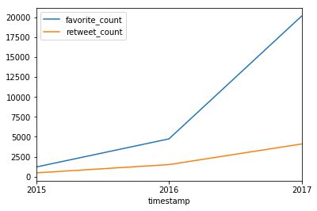

```python
tweets_by_year.plot();
```

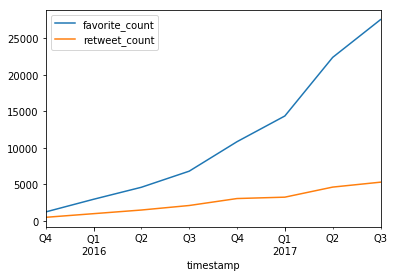

```python
tweets_by_quarter.plot();
```

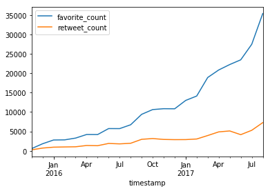

```python
tweets_by_month.plot();
```

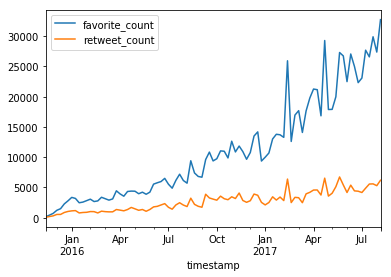

```python
tweets_by_week.plot();
```

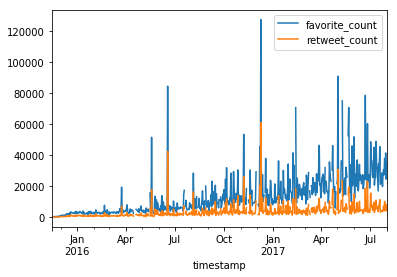

```python
tweets_by_day.plot();
```

Our tweets_by_week plot is (arguably) probably the most useful of these, so I'll use this one and pretty it up a bit.

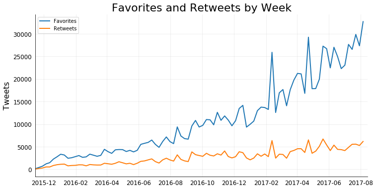

```python
fig, ax = plt.subplots(1, 1, figsize=(12, 6))
plt.plot(tweets_by_week.index, tweets_by_week.favorite_count, linewidth=2.0, label='Favorites');
plt.plot(tweets_by_week.index, tweets_by_week.retweet_count, linewidth=2.0, label='Retweets');
ax.spines['top'].set_visible(False); # Getting rid of top spine
ax.spines['right'].set_visible(False); # Getting rid of right spine
ax.set_xlim('2015-11-15', '2017-08-15'); # Getting rid of whitespace
plt.xticks(fontsize=12)
plt.yticks(fontsize=12)
plt.tick_params(axis='both', which='both', bottom=False, top=False,
                labelbottom=True, left=False, right=False, labelleft=True); # Hiding unnecessary tick marks
plt.ylabel('Tweets', fontsize=16);
plt.title('Favorites and Retweets by Week', fontsize=22);
plt.legend();
plt.grid(True, alpha=0.25); # Showing a light gray grid to help visual alignment
plt.savefig('tweets_by_week.png', bbox_inches='tight')
plt.show()
```